# tidybreed Quick Start Guide

v0.27.0

Author

Austin Putz

Published

May 17, 2026

[figure not shown]

## Disclaimer!

**BETA VERSION:** This package is **pre v1.0.0** which means it’s highly **unstable** as development is very heavy. When a package or software is < `v1.0.0` it’s considered in beta testing basically.

Don’t rely too heavily on this package just yet.

No official manual yet until `v1.0.0` so I’ll likely use this document to show users the key features.

## `tidybreed` Package - Simulating breeding programs

### What does a breeding program consist of?

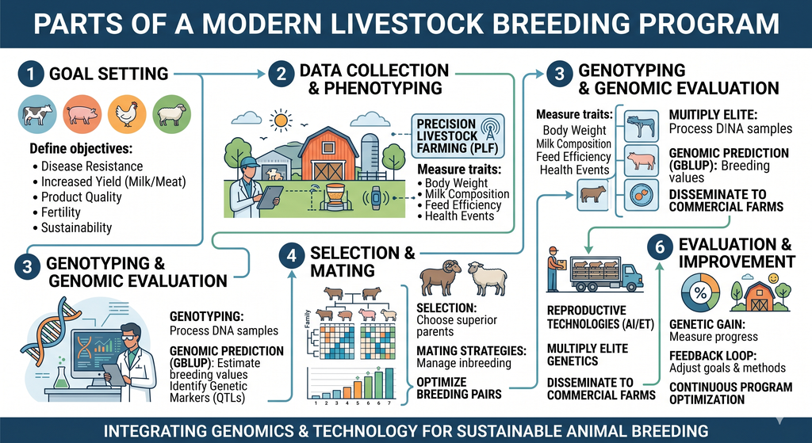

via ChatGPT Image - BP Overview

This leaves us with nearly *infinite combinations* in terms of possibilities. 2^20 is over 1,000,000 possibilities which just scratches the surface of breeding program design.

Users will need a way to build a breeding program with simple stepwise tools designed to do one thing at at time and slowly build up the breeding program.

Flexibility is needed at every turn including QTL ‘architecture’ (Dan Gianola loves this term!), genotyping, traits/phenotypes (very diverse), ways to select/mate, who gets phenotyped at what time and when evaluations are ran. Hard coding anything will be a feeble attempt, functions just need to take what they have and produce output. Users can change anything between 2 functions to modify or add to tables as they like.

Prime **example**: Package doesn’t have the correct phenotype for your breeding system trait of interest. `tidybreed` says, pull the true breeding value from `ind_tbv` (table) and add a residual and do whatever you want to make it the phenotype you want. Push that new phenotype back into the `ind_phenotype` table on your own, shhhh `tidybreed` won’t even know it happened.. Future functions such as `add_ebv()` will just pull all those phenotypes and calculate EBVs regardless of what you did. Nothing to clash with in a web of code design or any concrete meta data that will causes errors downstream.

### Theory / Design Principles

The **theory** & **design** is straightforward:

- Use **R**
  - Why? Because it’s become the standard language for many scientists
  - Hadley revolutionized it with his implementation of piping in `ggplot2` and now `tidyverse`
  - Only core functions need to be extremely efficient and to handle important operations such as creating haplotypes
- Use the **pipe** (`%>%` from `magrittr`) or (`|>` native R now) pipe to make it feel like `tidyverse`
  - This allows users to select (`filter()`) exactly the animals they want to **phenotype** or **genotype**
  - Then users can also use `filter` for selection and mating schemes
  - Users likely already know `dplyr` and the pipe operator, reducing the learning curve
- Use a **modern database** (`duckdb` chosen)
  - All data can/should be stored in a relational DB as they are in real breeding programs
  - Allows ‘lazy’ loading (not loading in memory)
  - Allows very efficient processing for large simulations as DBs are notorious for this
  - Save to disk to save memory, leading to realistic population sizes without worrying about memory
- **Flexibility**
  - Users will want to add/edit/modify/extend/etc
  - With the use of **‘exposed’ database tables**, users can change/modify basically anything they want (with great power comes great responsibility)
  - Let’s say a **phenotype** you want is *not available* as a function or argument (e.g. social genetic effects, simply pull the data you want, calculate the phenotype you want, insert it into the phenotype table and continue your simulation)
- Start with a **generic, flexible function**. Later provide helper/wrapper functions.
  - e.g. for matings, `tidybreed` uses `add_offspring()` that takes a `tibble` as input with the parent IDs, sex, and line_name. Which allows users to mate any way they like and produce as many offspring as they like (don’t need to wait for a developer to design a scheme you use)
  - for ease of use and cleaner code, we can provide ‘helper/wrapper’ functions to produce that `tibble` mating plan
  - This allows you to **“do anything”** while also making it easier to learn
- **Documentation**: Exposing the user to the data allows them to “see” what is going on much easier than packages built to “do everything” internally for the user and possibly not return needed information
  - Leads to better transparency for the user to document steps exactly for publication
  - might be more verbose to start for simple programs (like `tidyverse`), hopefully less for more complex programs

**Drawbacks to `tidybreed`**

- Users may want/need to learn SQL (use `DBI` package) to perform the most complex operations but not required
- New users might see fewer wrapper/helper functions for users with simple breeding programs
  - later users will see why `tidyverse` is so verbose and why `tidybreed` copied this core philosophy
- Unlimited ability to add/alter any data in any table the user wants could lead to mistakes/bugs
  - **Disclaimer** - this is not the author’s problem and no warranty or liability attached to this software
  - **Use at your own risk**

### Just one example

At one point I wanted to simulate mutations in the recent selections I was performing with a software package (well developed but lacked functionality for this).

With `tidybreed` the haplotypes are ‘exposed’ to the user for easy manipulation. Users can ‘easily’ change a locus from 0 to 1 or 1 to 0 to simulate mutation in any haplotype they choose (just like gene editing).

Users can then go into the `genome_effects` table and **change the QTL effects** that are also ‘exposed’ to the user in an easy/straightforward way.

The result is that users no longer have to wait for development, just **add/alter** **anything you want** and there end up being very few things the user cannot manipulate easily on their own.

### Why use a database?

Simulation programs only really need to consist of a **few very basic functions**. At the very core is to **simply produce haplotypes as efficiently as possible** and store them as efficiently as possible (reduce RAM and hard disk memory usage). The rest should basically be available to the user to determine and alter as needed to mimic their breeding program as closely as possible. For simple questions, using “generation” may suffice, but often breeding programs are much more complex in real life and timing is critical (i.e. need dates for everything).

Everything beyond creating haplotypes efficiently is **simple data storage** and all programs need to store different types of data. Some breeding programs may be simple with no threshold traits. Others may consist of many threshold traits such as mortality. Fish can be mated very differently than livestock, since fish can create a massive number of eggs and be fertilized by many different males. Crop species are more complex yet, even at a genome level (beyond 2n, etc).

Most data in the world can or has been stored in relational databases and there are entire degrees devoted to storing data in databases. R has a very odd and goofy attachment to `lists` only.

Database exposure to users allows them to basically add infinite functionality through adding their own columns/fields, rows, individuals, tables, traits, phenotypes etc to the database. You no longer have to wait for the developer to add a function, users can pull the data they need, calculate what they need, and import it back into the database through a table.

Developers will always be behind adding functionality for other external programs and as soon as they are added as features, the external software will update and need maintained excessively.

**Why are dates critical**

Have you thought about selecting a purebred animal for a crossbred trait with crossbred siblings?

If all gilts/sows for a boar are mated at the day, the purebred progeny will likely finish before the crossbred progeny (i.e. healthier). Therefore using discrete generations in simulation is mostly useless and you have to start doing many workarounds to simulate that program. Way more intricate designs can be simulated with dates.

The implication is that we should and need to separate phenotyping, genotype timing, evaluations, etc. and have an unlimited way of adding or altering tables, rows, columns, etc. `tidybreed` allows users to work with **dates** easily by adding them to any table they want.

Simulation of real world breeding programs is now possible without excessive modifications or faking generation as a date.

#### Why DuckDB?

[DuckDB](https://duckdb.org/) was chosen for `tidybreed` to serve the database layer There are many options but in general the thoughts were as follows:

- Modern (v1.0 in 2024)
- Good R package support/integration (runs in R with no external downloads)
- use SQL via `dbplyr` package
- Fast (basically all databases need to be efficient)
- Free and open-source!
- Simulate huge populations without running out of memory (RAM)

I believe with UTINYINT we can store 50,000 loci for 50,000 individuals on disk for ~700Mb and 7.5GB in RAM. However, the user should never need to pull all those into RAM to calculate anything unless they have a good reason. Users should pull the rows they need, calculate, recycle memory for the next process. Users can also **delete rows** as they go through the simulation to keep memory low.

# Install `tidybreed`

There are 2 ways:

- Via `devtools` package (if you have the repo cloned locally)
  - `load_all()` - will jsut load all code (quicker)
  - `install()` - will ‘install’ the package and render markdowns for docs, etc
- Via **GitHub** using the `pak` package

You can choose how to install `tidybreed` with the following T/F options:

```r
# set install options for tidybreed
install_local  <- TRUE   # install from local directory with `pak`
install_github <- FALSE  # install from GitHub using 'pak' package

# path to tidybreed code for devtools
# SET TO YOUR LOCAL DIRECTORY!!! (defaults back to github if not found!!!)
path_tidybreed <- "/Users/austinputz/Claude/tidybreed/"
```

```r
# check options
if (all(install_local, install_github)){
  stop("Select either a local directory or GitHub for install please")
} else if (any(install_local, install_github) == FALSE){
  stop("Select either a local directory or GitHub for install please")
}

# check for path, if not found, fall back to GitHub download/install
if(dir.exists(path_tidybreed)){
  message("PATH to tidybreed package exists")
} else {
  warning("Didn't find your tidybreed directory, will pass to GitHub instead for install...\n")
  # fall back to GitHub if directory not found
  install_github <- TRUE
}
```

```
PATH to tidybreed package exists
```

### Use `pak` either way

`pak` is now the recommended standard for installing packages from anywhere (local, GitHub, CRAN), developed by Posit/RStudio.

```r
# call pak, install if needed
if ("pak" %in% installed.packages()){
  message("pak package installed, calling library(pak) now:\n")
  library(pak)
} else {
  warning("pak package not installed, need to install from CRAN...")
  install.packages("pak")   # install from CRAN
  library(pak)
}
```

```
pak package installed, calling library(pak) now:
```

### Via GitHub using `pak`

Find [tidybreed on GitHub](https://github.com/austin-putz/tidybreed).

Install `tidybreed` via `pak` from **GitHub**:

```r
# if not installed or updated from GitHub
if (install_github == TRUE){

  message("Installing from GitHub, check PATH if wanted local install above\n")

  # install tidybreed from GitHub with pak package
  pak::pak("austin-putz/tidybreed", upgrade = TRUE)

  # load tidybreed
  library(tidybreed)

} else {
  warning("Will install from local directory, make sure it's up to date!")
}
```

### Via local directory with `pak`

Install `tidybreed` via `pak` if you have a local directory, such as a clone from GitHub maybe

Could use `devtools` with:

- use `load_all()` for quick loading
- use `install()` + `library()` for “full install/build”

but don’t let me micromanage you.

```r
# load the current version (test new functionality before commit to GitHub)
if (install_local == TRUE){
  # install tidybreed locally
  pak::pak(path_tidybreed, upgrade = TRUE)
}
```

[output not shown]

[output not shown]

[output not shown]

[output not shown]

[output not shown]

[output not shown]

[output not shown]

[output not shown]

[output not shown]

[output not shown]

[output not shown]

[output not shown]

[output not shown]

Make sure to load just in case

```r
library(tidybreed)
```

### Other packages

Load any other packages you want here, probably recommend `tidyverse` at minimum, but avoid too many if they could conflict with `tidybreed`.

```r
# load other libraries
library(tidyverse)
```

# Start Breeding Program

## Step 1: Build a generic genome

The most important first step is to design the genome as this is typically “fixed” for any population (although long we know genomes also evolve slowly).

The other core design is to use databases so it needs to initialize a few core tables used throughout this package.

**Important Notes:**

**LOCI:** You are only designing the number of loci for the genome that can be utilized later as QTL or (SNP) Markers. There is no need to assign which are SNP or QTL because ‘full’ haplotypes will need to be created through gametes/recombination anyway. Later, we can specify and detail a locus as a SNP or QTL and assign effects.

> NOTE: As of 2026-04-30 and version 0.9.4, I simply generate random 0/1 haplotypes per locus sampling from a uniform distribution or whatever you choose in the arguments available. Before launching v1.0.0 I will have the functionality to generate LD from MACS or through random selection over many generations with recombination and mutation.

**New Function:** `initialize_genome()` will build a genome for this population based on the number of loci, chromosomes, and length of each chromosome in Mb. Also, it can draw random haplotypes to sample from later when creating “base” or “founder” individuals to begin the population. `tidybreed` uses a floating point number in Mb such as `1.25` Mb (1,250,000 bp).

1 Mb = 1,000,000 base pairs

You may need to alter your SNP map/manifest file to Mb and not base pairs.

```r
#------------------------------------------------------------------------------#
# Begin Population (Genome)
#------------------------------------------------------------------------------#

# start population by building a genome
pop <- initialize_genome(
         pop_name   = "Test",   # different than "line_name" below, this is the entire genome + DB name
             n_loci     = 100,      # number of loci (nothing assigned as SNP or QTL yet...)
             n_chr      = 2,        # number of chromosomes
             chr_len_Mb = 50,       # length in Mb (1,000,000 bp) (e.g. 1.20 and not 1_200_000)
             n_haplotypes = 200,    # number of random haplotypes generated (no LD generated)
             overwrite = TRUE       # overwrite the database if it exists from a previous run
          )
```

```
Overwriting existing database: Test_tidybreed.duckdb
```

```
Generating 200 founder haplotypes...
```

```
  Allele frequencies sampled from uniform(0.01, 0.99)
```

```
  Created founder_haplotypes table
```

```
Initialized population 'Test' with 100 loci across 2 chromosomes
```

```
  Generated 200 founder haplotypes
```

```
Database: Test_tidybreed.duckdb
```

**Created tables:**

**UPDATE** as of `v0.9.0` the `initialize_genome()` function **“greedily”** **adds tables**.

**Why?** Because I wanted users not to be confused by what function added the tables and wanted users to be adding columns very early on to be able to add new field values (user defined columns) when they first call a function such as `add_ebv()`, this will be very valuable instead of calling the same rows twice in a second step that would be error prone for users copying and pasting (or changing 1 and not the other, very bad design).

Now users can examine all important tables and add user defined fields very early in your script. Avoid adding them mid loop.

- `genome_meta` - stores info per locus (like number/name/chr/position/SNP/etc)
  - **1 line per loci**
- `genome_effects` - QTL effect data (locus × trait × effect type); one row per QTL effect.
  - Written by `add_additive_effects()`. A locus is a QTL for a trait if it has a row here.
- `genome_haplotype` - all 0/1 loci haplotypes for each individual
  - **2 rows per individual**
  - row 1: haplotype from parent 1 or “sire” in livestock
  - row 2: haplotype from parent 2 or “dam” in livestock
- `genome_genotype` - all loci genotypes for each individual
  - **1 row per individual**
- `founder_haplotypes` - founder haplotypes (currently randomly generated, **no LD**)
- `ind_meta` - individual data
  - **1 line per individual**
- `trait_effect_cov` - trait (co)variances (matrix in row/col format)
  - **1 line for each (co)variance** value
- `trait_meta` - trait info such as name, units, type, sex limited, etc
  - **1 line per trait**
- `trait_effects` - fixed effects per trait
- `trait_random_effects` - random effect per trait
- `ind_phenotype` - individual phenotypes per trait
  - **1 line per phenotype**
  - therefore ‘long’ format with traits stacked on top of each other
- `ind_tbv` - individual true breeding values (TBVs) from additive effects
- `ind_ebv` - individual estimated breeding values (EBVs)
  - **1 line per trait, per evaluation run (integer)**
  - if you run `add_ebv()` twice on the same animals, you will have 2x EBV values / ind
- `index_meta` - index information (index name, trait name, weight)
  - **1 line per trait weight per index**
- `ind_index` - indexes calculated from `add_index()`
  - **1 line per individual per index calculation**
  - Increases ‘index_number’ by 1 each round
- `ind_true_index` - true selection index values from TBVs (written by `add_tbv()` when `index_names` supplied)
  - **1 line per individual per index per weight type**

You should also notice it created a file called **Test_tidybreed.duckdb** in your working directory which is your Duck Database with tables!

```r
list.files(pattern="duckdb")
```

```
[1] "Test_tidybreed.duckdb"     "Test_tidybreed.duckdb.wal"
```

**New Function:** `get_table()` use to extract any table in the database. Use `collect()` after pulling a table to convert to `tibble` and pull into memory.

View any table with the `get_table()` helper function. Understand that this is just a “view” of the database table and not pulling it into R yet. But very important to view these to understand each table.

```r
pop %>%
  get_table("genome_meta")
```

```
<tidybreed_table: genome_meta>  [100 rows × 6 fields]
# A tibble: 10 × 6
   locus_id locus_name   chr chr_name pos_Mb founder_allele_freq
      <int> <chr>      <int> <chr>     <dbl>               <dbl>
 1        1 Locus_1        1 1         0.980              0.865
 2        2 Locus_2        1 1         1.96               0.675
 3        3 Locus_3        1 1         2.94               0.460
 4        4 Locus_4        1 1         3.92               0.667
 5        5 Locus_5        1 1         4.90               0.779
 6        6 Locus_6        1 1         5.88               0.524
 7        7 Locus_7        1 1         6.86               0.760
 8        8 Locus_8        1 1         7.84               0.0499
 9        9 Locus_9        1 1         8.82               0.862
10       10 Locus_10       1 1         9.80               0.637
```

I did update how `get_table()` prints to screen vs if you use `print()` but I’ll let you explore more to decide yourself which you prefer.

## Step 2: Add your own fields / columns

Before we begin, there is one design principle I added in `v0.9.0` that is a big improvement, but was a huge refactor of the codebase. We now suggest to define **user defined fields** early and that means `initialize_genome()` creates a lot of new tables than before.

Users should define **new columns/fields** early and pass values to those new columns in the `add_*()` functions such as `add_founders()` or `add_offspring()`, `add_phenotypes()`, etc.

**New Function:** Use `mutate_table()` to add your own custom fields/columns to any tables. To my knowledge, none of my functions break but I have not explored this extensively so report back asap if they break a function.

Here we use `mutate_table()` to add/modify ANY column/field you want to the `ind_meta` table. This means we can use many other fields to filter/select animals later on for phenotyping/genotyping/selection/mating/etc. This will be very powerful later!

Let’s create **3 new custom fields** for the `ind_meta` table as follows:

```r
# create THREE (3) new CUSTOM Columns/Fields
pop %>%
  get_table("ind_meta") %>%
  mutate_table(
    gen = NA_integer_,           # initialize 'generation' as 'integer'
    farm = NA_character_,        # initialize 'farm' as 'character' (VARCHAR in SQL)
    date_birth = NA_Date_        # initialize 'birth date' as 'Date' (DATE in SQL)
  )
```

```
Added new column 'gen' (INTEGER) to `ind_meta` (table is currently empty)
```

```
Added new column 'farm' (VARCHAR) to `ind_meta` (table is currently empty)
```

```
Added new column 'date_birth' (DATE) to `ind_meta` (table is currently empty)
```

We can initialize as above with just the type and using missing value (NULL or NA) as a default.

What if we want a default value like `FALSE` instead of just missing?

We can use the `.set_default` option in `mutate_table()` for users.

```r
pop %>%
  get_table("ind_meta") %>%
  mutate_table(
    active = FALSE,
    .set_default = TRUE
  )
```

```
Added new column 'active' (BOOLEAN) to `ind_meta` (table is currently empty) with DEFAULT
```

## Step 3: Add some founder or base individuals

Here we simply **sample haplotypes** created in `initialize_genome()` by using `add_founders()`.

> Note: I tried to keep `add_*()` for adding rows to tables and `mutate_*()` for adding columns or changing data in tables

Only need to know the number of males and females to sample to create a “base population” or “founders”.

Provide a line name so later you can add a separate line if you desire for crossbreeding or splitting the same population into 2 later.

```r
# add founders
pop <- pop %>%
  add_founders(       # add_*() functions typically add rows
    n_males   = 2,    # sample 2 males from haplotypes generated in `initialize_genome()`
    n_females = 8,    # sample 8 females from haplotypes generated in `initialize_genome()`
    line_name = "A",  # add name of his line (can have > 1 line per population)
    gen = 0L,                              # USER DEFINED ABOVE
    farm = "SowFarm1",                     # USER DEFINED ABOVE
    date_birth = as.Date("2026-01-01")     # USER DEFINED ABOVE
  )
```

```
Added 10 founders (2 males, 8 females) to line 'A'
```

Only **5 default columns/fields** in `ind_meta` created by `add_founders()`:

1. `id_ind`
2. `id_parent_1`
3. `id_parent_2`
4. `line_name`
5. `sex`

This is the only basic data a simulation package needs (in my opinion).

You could argue `line_name` and possibly `sex` is not needed. I might agree but here we are…

The rest are custom fields added to the table above:

6.`gen` - generation number 7. `farm` - farm name (location) 8. `date_birth` - date of birth (important for phenotyping + selection later)

> NOTE: I chose to implement ‘NULL’ (SQL) and ‘NA’ (R) so remember before exporting pedigrees where **programs may use 0 for missing parents**

View new `ind_meta` table:

```r
# get table of individuals "meta" data (basic info, 1 line per animal!)
pop %>%
  get_table("ind_meta") %>%
  print(n=10)
```

```
<tidybreed_table: ind_meta>  [10 rows × 9 fields]
# A tibble: 10 × 9
   id_ind id_parent_1 id_parent_2 line_name sex     gen farm   date_birth active
   <chr>  <chr>       <chr>       <chr>     <chr> <int> <chr>  <date>     <lgl>
 1 A_1    <NA>        <NA>        A         M         0 SowFa… 2026-01-01 FALSE
 2 A_2    <NA>        <NA>        A         M         0 SowFa… 2026-01-01 FALSE
 3 A_3    <NA>        <NA>        A         F         0 SowFa… 2026-01-01 FALSE
 4 A_4    <NA>        <NA>        A         F         0 SowFa… 2026-01-01 FALSE
 5 A_5    <NA>        <NA>        A         F         0 SowFa… 2026-01-01 FALSE
 6 A_6    <NA>        <NA>        A         F         0 SowFa… 2026-01-01 FALSE
 7 A_7    <NA>        <NA>        A         F         0 SowFa… 2026-01-01 FALSE
 8 A_8    <NA>        <NA>        A         F         0 SowFa… 2026-01-01 FALSE
 9 A_9    <NA>        <NA>        A         F         0 SowFa… 2026-01-01 FALSE
10 A_10   <NA>        <NA>        A         F         0 SowFa… 2026-01-01 FALSE
```

Notice we gave values for `gen`, `farm`, and `date_birth` otherwise they would have been `NA` in R and `NULL` in DuckDB SQL.

> NOTE: You can remove the `print()` function and it will print slightly differently

We can also initialize a new column and assign it a value for all individuals. The type will be inferred with the first non-missing value.

```r
# add custom field 'on the fly' (such as replicate)
pop <- pop %>%
  get_table("ind_meta") %>%   # will pull this table to work on below
  mutate_table(               # will take ANY table from `get_table()`
    rep = 1L                  # add 'replicate' to this table "on the fly"
  )
```

```
Added new column 'rep' (INTEGER) to `ind_meta`; 10 rows set
```

Now we added **5 new fields/columns** to `ind_meta` and we can view that updated table with the following helper function.

```r
# print ind_meta table
pop %>%
  get_table("ind_meta")
```

```
<tidybreed_table: ind_meta>  [10 rows × 10 fields]
# A tibble: 10 × 10
   id_ind id_parent_1 id_parent_2 line_name sex     gen farm   date_birth active
   <chr>  <chr>       <chr>       <chr>     <chr> <int> <chr>  <date>     <lgl>
 1 A_1    <NA>        <NA>        A         M         0 SowFa… 2026-01-01 FALSE
 2 A_2    <NA>        <NA>        A         M         0 SowFa… 2026-01-01 FALSE
 3 A_3    <NA>        <NA>        A         F         0 SowFa… 2026-01-01 FALSE
 4 A_4    <NA>        <NA>        A         F         0 SowFa… 2026-01-01 FALSE
 5 A_5    <NA>        <NA>        A         F         0 SowFa… 2026-01-01 FALSE
 6 A_6    <NA>        <NA>        A         F         0 SowFa… 2026-01-01 FALSE
 7 A_7    <NA>        <NA>        A         F         0 SowFa… 2026-01-01 FALSE
 8 A_8    <NA>        <NA>        A         F         0 SowFa… 2026-01-01 FALSE
 9 A_9    <NA>        <NA>        A         F         0 SowFa… 2026-01-01 FALSE
10 A_10   <NA>        <NA>        A         F         0 SowFa… 2026-01-01 FALSE
# ℹ 1 more variable: rep <int>
```

Now you may have a **“light bulb” moment** realizing how powerful using dates can be. You can now easily use real dates and timelines for your breeding program to answer much more complex questions that is unnatural or forces users to create complex workarounds to answer them.

Not only can we add columns (`mutate` adds columns in `dplyr`), but **we can alter any subset** using `filter()`.

Here we can simulate **“moving” an animal** to new farm like a boar stud for all the males. Later, we may want to use this for selecting boars if this is a pig breeding scheme.

```r
# change the "farm" for all males in the population (going to an AI Stud)
pop %>%
  get_table("ind_meta") %>%
  filter(sex == "M") %>%      # update only males below
  mutate_table(
    farm = "Boar-Stud-1"   # change farm name for only males using `filter()` above
  )
```

```
Warning: 'farm': replaced 2 existing values in `ind_meta` [2 of 10 rows]
```

**NOTICE:** You get a yellow warning (if in REPL) to alert the user 2 non-missing values were replaced by this function. Make sure to pay attention if you are mistakenly changing data you don’t mean to!

Let’s print the table to view our handy work:

```r
# print ind_meta table
pop %>%
  get_table("ind_meta")
```

```
<tidybreed_table: ind_meta>  [10 rows × 10 fields]
# A tibble: 10 × 10
   id_ind id_parent_1 id_parent_2 line_name sex     gen farm   date_birth active
   <chr>  <chr>       <chr>       <chr>     <chr> <int> <chr>  <date>     <lgl>
 1 A_1    <NA>        <NA>        A         M         0 Boar-… 2026-01-01 FALSE
 2 A_2    <NA>        <NA>        A         M         0 Boar-… 2026-01-01 FALSE
 3 A_3    <NA>        <NA>        A         F         0 SowFa… 2026-01-01 FALSE
 4 A_4    <NA>        <NA>        A         F         0 SowFa… 2026-01-01 FALSE
 5 A_5    <NA>        <NA>        A         F         0 SowFa… 2026-01-01 FALSE
 6 A_6    <NA>        <NA>        A         F         0 SowFa… 2026-01-01 FALSE
 7 A_7    <NA>        <NA>        A         F         0 SowFa… 2026-01-01 FALSE
 8 A_8    <NA>        <NA>        A         F         0 SowFa… 2026-01-01 FALSE
 9 A_9    <NA>        <NA>        A         F         0 SowFa… 2026-01-01 FALSE
10 A_10   <NA>        <NA>        A         F         0 SowFa… 2026-01-01 FALSE
# ℹ 1 more variable: rep <int>
```

Now there are 2 different “farms” in our simulation that can be utilized to group/filter animals later instead of just males/females.

> **Question:** YO! WHY YOU NAME FIELDS LIKE THAT DUMMY?? **Answer:** SQL convention I guess… I’m a camel case guy..

> **Question:** WHY DO YOU USE “id_parent_1” and “id_parent_2”?? **Answer:** To keep generic for animal or plant breeders that may use different language

### Using `dplyr`

Most users of R already know `dplyr` and there is no reason to avoid it’s use.

If you want to pull and manipulate data from a table such as `ind_meta` you must pull it into R memory with `collect()`, this allows users to continue to summarize with `dplyr` such as `group_by()`, `filter()`, `select()`, `summarise()` and so on…

Users now no longer need to worry about what may or may not be returned or stored for them.

```r
#------------------------------------------------------------------------------#
# Use collect() to pull in as tibble (data frame)
#------------------------------------------------------------------------------#

# collect() will return a tibble!
pop %>%
  get_table("ind_meta") %>%
  collect()               # converts database table "view" to a 'tibble'/dataframe in R
```

```
# A tibble: 10 × 10
   id_ind id_parent_1 id_parent_2 line_name sex     gen farm   date_birth active
   <chr>  <chr>       <chr>       <chr>     <chr> <int> <chr>  <date>     <lgl>
 1 A_1    <NA>        <NA>        A         M         0 Boar-… 2026-01-01 FALSE
 2 A_2    <NA>        <NA>        A         M         0 Boar-… 2026-01-01 FALSE
 3 A_3    <NA>        <NA>        A         F         0 SowFa… 2026-01-01 FALSE
 4 A_4    <NA>        <NA>        A         F         0 SowFa… 2026-01-01 FALSE
 5 A_5    <NA>        <NA>        A         F         0 SowFa… 2026-01-01 FALSE
 6 A_6    <NA>        <NA>        A         F         0 SowFa… 2026-01-01 FALSE
 7 A_7    <NA>        <NA>        A         F         0 SowFa… 2026-01-01 FALSE
 8 A_8    <NA>        <NA>        A         F         0 SowFa… 2026-01-01 FALSE
 9 A_9    <NA>        <NA>        A         F         0 SowFa… 2026-01-01 FALSE
10 A_10   <NA>        <NA>        A         F         0 SowFa… 2026-01-01 FALSE
# ℹ 1 more variable: rep <int>
```

Now the user has 2 farms in the database table for later.

This is very powerful as now you calculate whatever the hell you want and don’t need to ask package authors for the ability to track something… Or having to store it yourself outside their package. It’s your data and you do what you want with it.

**Question:** “Hey I want to know how many males and females I have”

**Answer:** Just use the following pipe structure, only have to first call the table you want.

```r
pop %>%
  get_table("ind_meta") %>%   # pull all data from 'ind_meta'
  collect() %>%               # DON'T FORGET to "pull" data into R tibble with collect()
  group_by(sex) %>%           # normal dplyr function
  summarise(                  # normal dplyr function
    n = n()
  )
```

```
# A tibble: 2 × 2
  sex       n
  <chr> <int>
1 F         8
2 M         2
```

**BOOM** you have your counts.**You can do this for any table.**

As a general design principle, I don’t care to store values in an object that becomes awkward to manage and leads to discrepancies such as if you add something in an internal “table” within an R function, it may not be reflected in the defined meta-data, leading to possible bugs. If I want the users to be able to add a new loci, I don’t want to store `n_loci` inside an object name. There are a few advantages, but I believe more issues than advantages overall.

Remember you can query a table with `filter()` and such before we view our tables.

```r
pop %>%
  get_table("ind_meta") %>%
  filter(sex == "M")
```

```
<tidybreed_table: ind_meta>  [10 rows × 10 fields]
Filter: sex == "M"
# A tibble: 2 × 10
  id_ind id_parent_1 id_parent_2 line_name sex     gen farm    date_birth active
  <chr>  <chr>       <chr>       <chr>     <chr> <int> <chr>   <date>     <lgl>
1 A_1    <NA>        <NA>        A         M         0 Boar-S… 2026-01-01 FALSE
2 A_2    <NA>        <NA>        A         M         0 Boar-S… 2026-01-01 FALSE
# ℹ 1 more variable: rep <int>
```

We will use this `filter()` step later on to “select” animals for phenotyping, genotyping, or selection/mating steps (the **“secret sauce”** of `tidybreed`).

> NOTE: This above is returning a view from your database and not in R memory yet until you `collect()`

## Step 4: Build up your genome info

In simulated breeding programs we often need to do **2 general things** that impact the genome or genomic selection.

1. **Add a “SNP Chip”**
   - add genotype information on individuals for genomic selection
   - “observed loci” in the genome (rest still unknown)
   - i.e. identify/select **which loci are “SNP”** (often not causal QTL)
   - ability to genotype individuals with different “SNP Chips”
2. **Add traits** -
   - sample loci to be **QTL** and **draw effects** from some distribution
   - often **scaled** somehow to achieve the **genetic variance** desired
   - often sampled in a **correlated** way such as for **multi-trait** selection with genetic correlations

**NOTE:** Adding **traits** was by far the *hardest* thing to design and still far from perfect. May be many changes made in the future to address limitations or challenges from users.

### Step 4a: Add a SNP Chip

The main function we need is `mutate_table()` to add your own custom fields/columns to the `genome_meta` table in your database. You can use this function on any table in the database.

**Details:** Really all the SNP chip is to the software is a logical to identify which loci (created by `initialize_genome()` above) are SNP. Use a `logical` or `BOOLEAN` with `TRUE` / `FALSE` values.

First take a peak at the `genome_meta` table:

```r
# look into genome_meta table
pop %>%
  get_table("genome_meta") %>%
  print(n=5)
```

```
<tidybreed_table: genome_meta>  [100 rows × 6 fields]
# A tibble: 5 × 6
  locus_id locus_name   chr chr_name pos_Mb founder_allele_freq
     <int> <chr>      <int> <chr>     <dbl>               <dbl>
1        1 Locus_1        1 1         0.980               0.865
2        2 Locus_2        1 1         1.96                0.675
3        3 Locus_3        1 1         2.94                0.460
4        4 Locus_4        1 1         3.92                0.667
5        5 Locus_5        1 1         4.90                0.779
```

Notice: The total number of rows and columns is printed at the top next to the table name.

We can use `define_chip()` to mark loci as members of a named SNP chip. The function accepts a `tidybreed_table` from `get_table("genome_meta")` (optionally filtered or randomly sampled) and writes a `BOOLEAN` column `is_{chip_name}` to `genome_meta`.

Here we create a **“Low Density” SNP Chip** (cheaper) with only 30 SNP (100 total loci in this genome) by sampling randomly with `slice_sample()`:

```r
#------------------------------------------------------------------------------#
# Add a Low-Density SNP chip with define_chip()
#------------------------------------------------------------------------------#

# define low-density SNP chip: pipe genome_meta -> slice_sample -> define_chip
pop <- pop |>
  get_table("genome_meta") |>
  slice_sample(n = 30) |>
  define_chip("LD")
```

```
Defined chip 'LD' with 30 SNPs in column 'is_LD'
```

Now we have the loci for this SNP chip in `genome_meta` as `is_LD`.

**WARNING:** Be careful! If you name a trait later called “LD” (maybe loin depth), it could overwrite this SNP chip.

```r
# look into genome_meta table now with new SNP column
pop %>%
  get_table("genome_meta") %>%
  print()
```

```
<tidybreed_table: genome_meta>  [100 rows × 7 fields]
# A tibble: 10 × 7
   locus_id locus_name   chr chr_name pos_Mb founder_allele_freq is_LD
      <int> <chr>      <int> <chr>     <dbl>               <dbl> <lgl>
 1        1 Locus_1        1 1         0.980              0.865  FALSE
 2        2 Locus_2        1 1         1.96               0.675  TRUE
 3        3 Locus_3        1 1         2.94               0.460  FALSE
 4        4 Locus_4        1 1         3.92               0.667  FALSE
 5        5 Locus_5        1 1         4.90               0.779  FALSE
 6        6 Locus_6        1 1         5.88               0.524  FALSE
 7        7 Locus_7        1 1         6.86               0.760  FALSE
 8        8 Locus_8        1 1         7.84               0.0499 TRUE
 9        9 Locus_9        1 1         8.82               0.862  FALSE
10       10 Locus_10       1 1         9.80               0.637  FALSE
```

We can also create the **“High Density” SNP Chip** the same way with 90 loci:

```r
# add high-density SNP chip: sample 90 random loci and assign to HD chip
pop <- pop |>
  get_table("genome_meta") |>
  slice_sample(n = 90) |>
  define_chip("HD")
```

```
Defined chip 'HD' with 90 SNPs in column 'is_HD'
```

This adds `is_HD` as a boolean column to `genome_meta` marking 90 randomly sampled loci as the high-density chip members.

View an updated `genome_meta`:

```r
# look into genome_meta table now
pop %>%
  get_table("genome_meta") %>%
  print(n=10)
```

```
<tidybreed_table: genome_meta>  [100 rows × 8 fields]
# A tibble: 10 × 8
   locus_id locus_name   chr chr_name pos_Mb founder_allele_freq is_LD is_HD
      <int> <chr>      <int> <chr>     <dbl>               <dbl> <lgl> <lgl>
 1        1 Locus_1        1 1         0.980              0.865  FALSE TRUE
 2        2 Locus_2        1 1         1.96               0.675  TRUE  TRUE
 3        3 Locus_3        1 1         2.94               0.460  FALSE TRUE
 4        4 Locus_4        1 1         3.92               0.667  FALSE TRUE
 5        5 Locus_5        1 1         4.90               0.779  FALSE TRUE
 6        6 Locus_6        1 1         5.88               0.524  FALSE TRUE
 7        7 Locus_7        1 1         6.86               0.760  FALSE TRUE
 8        8 Locus_8        1 1         7.84               0.0499 TRUE  TRUE
 9        9 Locus_9        1 1         8.82               0.862  FALSE TRUE
10       10 Locus_10       1 1         9.80               0.637  FALSE TRUE
```

User now has access to a low-density (LD) and high-density (HD) SNP chip!

Later all we need to do is extract the loci (columns) in `genome_haplotype` or `genome_genotype` with this logical vector created to pull the correct “SNP Chip” for selection/evaluation.

### Step 4b: Add a trait

**BY FAR the most difficult part** of building a simulation program / package is how to design a way to phenotype animals. This is because **phenotypes** can be:

- Observed once or many times
  - individuals will only grow once
  - females may be mated many times throughout life
- Be continuous with or without limits
  - milk yield or feed intake per day cannot be negative (only 0)
- Be counts, binary, categorical
  - litter size is discrete and varies across species
  - threshold traits present many issues
  - categorical traits even more issues (such as evaluation software)
- Be linked to litter size (in pigs for instance)
  - the phenotype itself is linked to reproduction success
- Observed at very different stages in life
  - at birth (weight) vs at death (longevity)
- Be linked to the genotype or haplotype
  - genetically expressed from the paternal or maternal haplotype only
- Vary based on group (sex, age, prior selection, etc)
  - limited to one sex due to expense (feed intake) or fertility (litter size)
- Are genetically and environmentally correlated often times
  - do we know exactly how traits are genetically correlated?
  - how do we sample correlated effects if the events are separated in time?

We also don’t know some factors like how many total QTL even exist and what is the exact distribution?

You therefore need a ton of ‘meta data’ on the trait itself (e.g. is it repeatable?) before we can design the model for producing the phenotype and provide checks or ways for the user to achieve the desired outcome in realistic units.

Then you need a way to control that trait via the loci effects (**additive,** **dominant, or epistasis**).

This is no easy feat… Below is my best attempt thus far. If you have suggestions, please email me directly or I will have a place to submit anonymous feedback later on.

**Step 1:** Add genetic (co)variances and residual (co)variances

Obviously the diagonals are the variances but a variance is just a covariance of a random variable with itself.

```r
# additive genetic (CO)VARIANCES
mat.add.gen.vars <- matrix(c(0.90,    3.07,  0.21,
                             3.07, 1050.00, 17.80,
                             0.21,   17.80,  1.20),
                      nrow = 3, byrow=TRUE,
                      dimnames = list(c("NW", "ADG", "BF"), c("NW", "ADG", "BF")))

# residual (CO)VARIANCES
mat.res.vars <- matrix(c(8.10,   10.00,  0.65,
                        10.00, 2100.00, 10.00,
                         0.65,   10.00,  1.30),
                      nrow = 3, byrow=TRUE,
                      dimnames = list(c("NW", "ADG", "BF"), c("NW", "ADG", "BF")))
```

Now, we use `add_effect_cov_matrix()` to add the **genetic (co)variances** to a table.

```r
# add this additive genetic covariance matrix to a table with function
pop <- pop %>%
  add_effect_cov_matrix(
    effect_name = "gen_add",              # gen_add is a keyword, be careful
    cov_matrix  = mat.add.gen.vars
  )
```

```
Stored 'gen_add' covariance matrix for trait(s): NW, ADG, BF.
```

- `trait_effect_cov` - holds all random effects (co)variances to have one table to extract from

```r
pop %>%
  get_table("trait_effect_cov")
```

```
<tidybreed_table: trait_effect_cov>  [9 rows × 5 fields]
# A tibble: 9 × 5
  id_trait_effect_cov effect_name trait_name_1 trait_name_2 cov_value
                <int> <chr>       <chr>        <chr>            <dbl>
1                   1 gen_add     NW           NW                0.9
2                   2 gen_add     NW           ADG               3.07
3                   3 gen_add     NW           BF                0.21
4                   4 gen_add     ADG          NW                3.07
5                   5 gen_add     ADG          ADG            1050
6                   6 gen_add     ADG          BF               17.8
7                   7 gen_add     BF           NW                0.21
8                   8 gen_add     BF           ADG              17.8
9                   9 gen_add     BF           BF                1.2
```

Obviously if you want **variances** only just filter to extract them:

```r
pop %>%
  get_table("trait_effect_cov") %>%
  filter(trait_name_1 == trait_name_2)
```

```
<tidybreed_table: trait_effect_cov>  [9 rows × 5 fields]
Filter: trait_name_1 == trait_name_2
# A tibble: 3 × 5
  id_trait_effect_cov effect_name trait_name_1 trait_name_2 cov_value
                <int> <chr>       <chr>        <chr>            <dbl>
1                   1 gen_add     NW           NW                 0.9
2                   5 gen_add     ADG          ADG             1050
3                   9 gen_add     BF           BF                 1.2
```

Now add the **residual (co)variance** matrix:

```r
# add this additive genetic covariance matrix to a table with function
pop <- pop %>%
  add_effect_cov_matrix(
    effect_name = "residual",        # residual is a keyword, be careful
    cov_matrix  = mat.res.vars
  )
```

```
Stored 'residual' covariance matrix for trait(s): NW, ADG, BF.
```

Print only the residual (co)variances:

```r
pop %>%
  get_table("trait_effect_cov") %>%
  filter(effect_name == "residual")   # filter out the residual (co)variances only
```

```
<tidybreed_table: trait_effect_cov>  [18 rows × 5 fields]
Filter: effect_name == "residual"
# A tibble: 9 × 5
  id_trait_effect_cov effect_name trait_name_1 trait_name_2 cov_value
                <int> <chr>       <chr>        <chr>            <dbl>
1                  10 residual    NW           NW                8.1
2                  11 residual    NW           ADG              10
3                  12 residual    NW           BF                0.65
4                  13 residual    ADG          NW               10
5                  14 residual    ADG          ADG            2100
6                  15 residual    ADG          BF               10
7                  16 residual    BF           NW                0.65
8                  17 residual    BF           ADG              10
9                  18 residual    BF           BF                1.3
```

**Step 2:** Add a new trait (ADG) with meta data on it as follows:

```r
#------------------------------------------------------------#
# Add Trait
#------------------------------------------------------------#

# add ADG as a trait
pop <- pop %>%
  add_trait(
    trait_name  = "ADG",
    description = "Average Daily Gain",
    units       = "g/d",                  # grams per day during testing period
    trait_type  = "continuous",           # not categorical or binary
    repeatable  = FALSE,                  # only 1 phenotype per individual
    recorded_on = "self",                 # recorded on itself only
    target_add_mean = 0,     # mean TBV in 'base'
    #target_add_var  = 1082,  # additive variance target in 'base'
    #residual_var    = 2500,  # residual variance (target h2 ~0.30) - 'fixed'
    index_weight    = 1,     # index weight (not implemented yet)
    economic_value  = 0.02,  # economic value (not implemented yet)
    overwrite       = TRUE   # wipe this row if it exists and replace with this new data
  )
```

```
Added trait 'ADG' (type: continuous).
```

```r
pop
```

```
<tidybreed population>
Population: Test
Database: Test_tidybreed.duckdb
Tables: genome_meta, genome_haplotype, genome_genotype, ind_meta, trait_effect_cov, genome_effects, founder_haplotypes, trait_meta, trait_effects, trait_random_effects, ind_phenotype, ind_tbv, ind_ebv, index_meta, ind_index, ind_true_index
Individuals: 10
Loci: 100
Traits: 1
```

Let’s first look at the `trait_meta` table in our database. Remember 1 row per trait only (for now).

```r
# check trait_meta table
pop %>%
  get_table("trait_meta") %>%
  print(c=20)
```

```
<tidybreed_table: trait_meta>  [1 row × 19 fields]
# A tibble: 1 × 19
  id_trait trait_name description        units trait_type repeatable recorded_on
     <int> <chr>      <chr>              <chr> <chr>      <lgl>      <chr>
1        1 ADG        Average Daily Gain g/d   continuous FALSE      self
# ℹ 12 more variables: expressed_sex <chr>, expressed_parent <chr>,
#   target_add_mean <dbl>, min_value <dbl>, max_value <dbl>, prevalence <dbl>,
#   thresholds <chr>, index_weight <dbl>, economic_value <dbl>,
#   cat_values <chr>, cat_names <chr>, store_liability <lgl>
```

**Step 3:** Define which loci in the genome are QTL for this trait and set effects in one combined step.

As of v0.23.0, `add_additive_effects()` takes a `tidybreed_table` from `get_table("genome_meta")` as its first argument. The `filter()` or `slice_sample()` step determines which loci are QTL — no separate `define_qtl()` call is needed. Effects are written to the `genome_effects` table (not as columns in `genome_meta`).

> Remember, you can also just use `pop %>% get_table("genome_meta") %>% mutate_table()` to define these yourselves. You don’t need to rely on these helper functions.

```r
# add which loci are QTL and their effects in one pipe
pop <- pop |>
  get_table("genome_meta") |>
  slice_sample(n = 10) |>          # these 10 randomly sampled loci become QTL for ADG
  add_additive_effects(
    trait_name    = "ADG",         # trait name
    distribution  = "normal",      # distribution of QTL effects
    scale_to_target = TRUE,        # scale to meet additive variance target
    base          = "current_pop"  # use all animals in pop to standardize (or if filtered)
  )
```

```
Set additive effects for 10 QTL on trait 'ADG' (base: current_pop).
```

Now let’s view the QTL effects for ADG in the `genome_effects` table. A locus is a QTL for a trait if it has a row in `genome_effects` for that trait.

```r
# check genome_effects table for ADG QTL
pop %>%
  get_table("genome_effects") %>%      # effects live in genome_effects, not genome_meta
  filter(trait_name == "ADG") %>%
  print()
```

```
<tidybreed_table: genome_effects>  [10 rows × 7 fields]
Filter: trait_name == "ADG"
# A tibble: 10 × 7
   id_genome_effect locus_name line_name trait_name genome_effect_type
              <int> <chr>      <chr>     <chr>      <chr>
 1                1 Locus_11   <NA>      ADG        additive
 2                2 Locus_18   <NA>      ADG        additive
 3                3 Locus_19   <NA>      ADG        additive
 4                4 Locus_26   <NA>      ADG        additive
 5                5 Locus_47   <NA>      ADG        additive
 6                6 Locus_57   <NA>      ADG        additive
 7                7 Locus_79   <NA>      ADG        additive
 8                8 Locus_80   <NA>      ADG        additive
 9                9 Locus_82   <NA>      ADG        additive
10               10 Locus_98   <NA>      ADG        additive
# ℹ 2 more variables: genome_value <dbl>, base_allele_freq <dbl>
```

Key points about the new design:

- `add_additive_effects()` takes a filtered `tidybreed_table` from `get_table("genome_meta")` — the filtered rows define the QTL set
- Effects are written to `genome_effects` with `genome_effect_type = "additive"`
- QTL membership is **implicit**: a locus is a QTL if it has a row in `genome_effects` for that trait
- No `is_QTL_ADG` or `add_ADG` columns are added to `genome_meta`

**Step 4:** Calculate and store **TBVs**

Now, we can calculate perhaps the most important parameter for simulations, the **“True Breeding Value”** (**TBV**) of the individual.

By default, the philosophy was to **not calculate anything that wasn’t needed**.

**Why?** Think if you are doing a very large simulation, do we often care the difference in TBV at generation 2? Often no… We simply need to extract differences at the “end” of the simulation or periodically throughout. Therefore by default we can skip adding the TBV for these animals, however a helper function is available to easily calculate for any or all individuals.

The following should return a blank, no rows…

```r
# 'ind_tbv' table of True Breeding Values
pop %>% get_table("ind_tbv") %>% print()
```

```
<tidybreed_table: ind_tbv>  [0 rows × 4 fields]
# A tibble: 0 × 4
# ℹ 4 variables: id_tbv <int>, id_ind <chr>, trait_name <chr>, tbv_value <dbl>
```

Remember, we can add **custom fields** to any table for later.

> NOTE: As of v0.26.0, `add_tbv()` has a reserved `type` argument (valid values: `"index"`, `"economic"`, `"both"`) for true index computation. Use a different column name such as `calc_method` for user-defined fields to avoid a name clash.

```r
pop %>%
  get_table("ind_tbv") %>%
  mutate_table(
    calc_method = NA_character_   # user-defined field (avoid 'type' — it's reserved in add_tbv)
  )
```

```
Added new column 'calc_method' (VARCHAR) to `ind_tbv` (table is currently empty)
```

Now we calculate the ‘TBV’ for all animals in our population. For some simulations, it may not be needed or required (say you only want to study LD and will perform random selection anyway).

We pass the user defined field as an extra argument to add to those set of animals added into the `ind_tbv()` table.

```r
# calculate and store TBV for ADG trait
pop <- pop %>%
  get_table("ind_meta") %>% # here we specify the 'ind_meta' table so all animals will have their TBV calculated
  add_tbv(
    trait_name  = "ADG",
    calc_method = "additive"    # USER DEFINED above
  )
```

```
Computed TBV for 10 individuals on trait 'ADG'.
```

Note: `add_phenotype()` calls `add_tbv()` internally, so you don’t need to call `add_tbv()` separately before phenotyping. It is shown here explicitly so you can see how TBV computation works on its own.

Now look at our populated table. It will be very straightforward for the user to join this to whatever EBVs they calculate to calculate **population accuracies**.

```r
# now look at updated 'ind_tbv' table
pop %>% get_table("ind_tbv") %>% print()
```

```
<tidybreed_table: ind_tbv>  [10 rows × 5 fields]
# A tibble: 10 × 5
   id_tbv id_ind trait_name tbv_value calc_method
    <int> <chr>  <chr>          <dbl> <chr>
 1      8 A_8    ADG           -0.776 additive
 2      9 A_9    ADG          -12.3   additive
 3      5 A_5    ADG          -48.1   additive
 4      7 A_7    ADG           -2.62  additive
 5      6 A_6    ADG          -23.7   additive
 6     10 A_10   ADG           25.4   additive
 7      2 A_2    ADG          -40.2   additive
 8      1 A_1    ADG           19.5   additive
 9      3 A_3    ADG           68.8   additive
10      4 A_4    ADG           14.1   additive
```

Let’s look at the mean to verify it is centered to our target. Should be very close to 0.

```r
pop %>%
  get_table("ind_tbv") %>%
  collect() %>%
  summarise(
    MeanTBV = mean(tbv_value)
  )
```

```
# A tibble: 1 × 1
   MeanTBV
     <dbl>
1 4.62e-15
```

**Step 5:** Add some fixed effects

We can add **any custom fixed/random effects** per trait in the following way.

First, add an **overall mean** for ADG:

```r
# add overall mean
pop %>%
  add_effect_int(
    trait_name = "ADG",              # trait (need to change to "trait_name")
    mean = 1000
  )
```

```
Set intercept for trait 'ADG' to 1000.
```

Second, add ‘sex’ as a fixed effect for ADG:

```r
# add sex effect for ADG
pop %>%
  add_effect_fixed_class(
    trait_name = "ADG",
    effect_name = "sex",
    source_column = "sex",
    levels = c(M=200, F=0),
    source_table = "ind_meta",
    overwrite = TRUE
  )
```

```
Added fixed-class effect 'sex' to trait 'ADG' (2 levels).
```

Now we can view its “handy work” looking at the new table row in `trait_effects`. This makes it easy to simulate high/lower phenotypes like with real data.

> Question: Does this impact the simulation? Answer: Honestly, I’m not sure, but it’s more realistic so possibly…

```r
# look at effects table (should be nothing)
pop %>% get_table("trait_effects") %>% print()
```

```
<tidybreed_table: trait_effects>  [1 row × 10 fields]
# A tibble: 1 × 10
  trait_name effect_name effect_class source_column source_table distribution
  <chr>      <chr>       <chr>        <chr>         <chr>        <chr>
1 ADG        sex         fixed_class  sex           ind_meta     <NA>
# ℹ 4 more variables: levels_json <chr>, slope <dbl>, center <dbl>, value <dbl>
```

When you call `add_phenotype()` it will call this table to find effects.

> NOTE: Likely I will change the “date_calc” field so don’t rely on it yet

Let’s add a custom field to the `ind_phenotype` table:

```r
pop %>%
  get_table("ind_phenotype") %>%
  mutate_table(
    environment = NA_character_    # new column in 'ind_phenotype' table
  )
```

```
Added new column 'environment' (VARCHAR) to `ind_phenotype` (table is currently empty)
```

**Step 6:** Add phenotypes to all individuals in the population

Remember we need to always call `get_table()` before `add_phenotype()`.

Note: `add_phenotype()` calls `add_tbv()` internally, so TBVs are automatically computed and stored for any individual receiving a phenotype.

```r
# test `add_phenotype()` function
pop <- pop %>%
  get_table("ind_meta") %>%     # will phenotype all individuals in this table with no filter
  add_phenotype(                # add rows to 'ind_phenotye' table
    trait_name  = "ADG",        # trait name
    environment = "hot"         # USER DEFINED FIELD above
  )
```

```
Computed TBV for 10 individuals on trait 'ADG'.
```

```
Wrote 10 phenotype records for trait 'ADG'.
```

Look at the `ind_phenotype` table

```r
pop %>%
  get_table("ind_phenotype") %>%
  print(n=20)
```

```
<tidybreed_table: ind_phenotype>  [10 rows × 6 fields]
# A tibble: 10 × 6
   id_phenotype id_ind trait_name pheno_value pheno_number environment
          <int> <chr>  <chr>            <dbl>        <int> <chr>
 1            1 A_1    ADG              1259.            1 hot
 2            2 A_2    ADG              1268.            1 hot
 3            3 A_3    ADG              1089.            1 hot
 4            4 A_4    ADG               994.            1 hot
 5            5 A_5    ADG               933.            1 hot
 6            6 A_6    ADG               908.            1 hot
 7            7 A_7    ADG               995.            1 hot
 8            8 A_8    ADG               992.            1 hot
 9            9 A_9    ADG              1063.            1 hot
10           10 A_10   ADG              1011.            1 hot
```

The important feature to add is **“selecting” which animals receive a phenotype** at this point in the simulation. **Simply use the `filter()` function from dplyr** as follows:

```r
pop <- pop %>%
  get_table("ind_meta") %>%                # "select" within ind_meta only
  filter(sex == "M") %>%                   # "select" only males to phenotype for ADG
  add_phenotype(
    trait_name  = "ADG",
    environment = "cold"          # USER DEFINED
  )
```

```
Computed TBV for 2 individuals on trait 'ADG'.
```

This was the **“secret sauce”** (goal) developing this package. We add any data we want, and we “select” by using familiar piping and functions.

Now let’s view all our phenotypes stored in `ind_phenotype`:

```r
# look at 'ind_phenotype' table
pop %>%
  get_table("ind_phenotype") %>%    # added phenotypes for all IDs
  print(n=25)
```

```
<tidybreed_table: ind_phenotype>  [10 rows × 6 fields]
# A tibble: 10 × 6
   id_phenotype id_ind trait_name pheno_value pheno_number environment
          <int> <chr>  <chr>            <dbl>        <int> <chr>
 1            1 A_1    ADG              1259.            1 hot
 2            2 A_2    ADG              1268.            1 hot
 3            3 A_3    ADG              1089.            1 hot
 4            4 A_4    ADG               994.            1 hot
 5            5 A_5    ADG               933.            1 hot
 6            6 A_6    ADG               908.            1 hot
 7            7 A_7    ADG               995.            1 hot
 8            8 A_8    ADG               992.            1 hot
 9            9 A_9    ADG              1063.            1 hot
10           10 A_10   ADG              1011.            1 hot
```

### Add a 2nd Trait

Let’s add **Backfat (BF)** as a second trait to this simulation:

```r
#------------------------------------------------------------#
# Add Trait
#------------------------------------------------------------#

# add BF as a trait
pop <- pop %>%
  add_trait(
    trait_name = "BF",        # name of trait
    description = "Ultrasound  Backfat",   # what exactly is this trait?
    units = "mm",                          # grams per day during testing period
    trait_type = "continuous",             # not categorical or binary
    repeatable = FALSE,                    # only 1 phenotype per individual
    recorded_on = "self",                  # can be recorded on the dam, etc
    min_value = 0,           # backfat cannot be negative
    target_add_mean = 0,     # mean TBV in 'base'
    #target_add_var = 1.0,   # additive variance target in 'base'
    #residual_var = 1.0,     # residual variance (target h2 ~0.30) - 'fixed'
    index_weight = -1,        # index weight (not implemented yet)
    economic_value = -0.5,   # economic value (not implemented yet)
    overwrite = TRUE         # wipe this row if it exists and replace with this new data
  )
```

```
Added trait 'BF' (type: continuous).
```

Print `trait_meta` table

```r
pop %>% get_table("trait_meta") %>% print()
```

```
<tidybreed_table: trait_meta>  [2 rows × 19 fields]
# A tibble: 2 × 10
  id_trait trait_name description        units trait_type repeatable recorded_on
     <int> <chr>      <chr>              <chr> <chr>      <lgl>      <chr>
1        1 ADG        Average Daily Gain g/d   continuous FALSE      self
2        2 BF         Ultrasound  Backf… mm    continuous FALSE      self
# ℹ 3 more variables: expressed_sex <chr>, expressed_parent <chr>,
#   target_add_mean <dbl>
# … with 9 more fields: min_value, max_value, prevalence, thresholds, index_weight, …
```

Now add loci as QTL and sample effects (with standardization).

```r
# set QTL loci and QTL effects for BF in one pipe
pop <- pop |>
  get_table("genome_meta") |>
  slice_sample(n = 10) |>          # 10 randomly sampled loci become QTL for BF
  add_additive_effects(
    trait_name    = "BF",          # trait name
    distribution  = "normal",      # distribution of QTL effects
    scale_to_target = TRUE,        # scale to meet additive variance target
    base          = "current_pop"  # use all animals in pop to standardize
  )
```

```
Set additive effects for 10 QTL on trait 'BF' (base: current_pop).
```

Add overall mean for BF:

```r
pop %>%
  add_effect_int(
    trait_name = "BF",      # name of trait
    mean = 10               # mm
  )
```

```
Set intercept for trait 'BF' to 10.
```

Calculate TBV for BF:

```r
pop <- pop %>%
  get_table("ind_meta") %>%
  add_tbv(trait_name = "BF")
```

```
Computed TBV for 10 individuals on trait 'BF'.
```

All individuals now have a TBV for ‘BF’. Let’s check the means for TBV for each trait.

```r
# calculate mean TBV for each trait
pop %>%
  get_table("ind_tbv") %>%
  collect() %>%
  group_by(trait_name) %>%
  summarise(
    MeanTBV = mean(tbv_value)
  )
```

```
# A tibble: 2 × 2
  trait_name   MeanTBV
  <chr>          <dbl>
1 ADG         4.62e-15
2 BF         -8.88e-17
```

Now let’s add some phenotypes for BF.

```r
pop <- pop %>%
  get_table("ind_meta") %>%
  add_phenotype(
    trait_name  = "BF",
    environment = "hot"
  )
```

```
Computed TBV for 10 individuals on trait 'BF'.
```

```
Wrote 10 phenotype records for trait 'BF'.
```

Now we can summarize the `ind_phenotype` table:

```r
pop %>%
  get_table("ind_phenotype") %>%
  collect() %>%
  group_by(trait_name) %>%
  summarise(
    MeanPheno = mean(pheno_value)
  )
```

```
# A tibble: 2 × 2
  trait_name MeanPheno
  <chr>          <dbl>
1 ADG          1051.
2 BF              9.64
```

Notice our mean phenotype should be close enough to our overall means.

Print all phenotypes in `ind_phenotype`:

```r
# look at 'ind_phenotype' table
pop %>%
  get_table("ind_phenotype") %>%    # added phenotypes for all IDs
  print(n=25)
```

```
<tidybreed_table: ind_phenotype>  [20 rows × 6 fields]
# A tibble: 20 × 6
   id_phenotype id_ind trait_name pheno_value pheno_number environment
          <int> <chr>  <chr>            <dbl>        <int> <chr>
 1            1 A_1    ADG            1259.              1 hot
 2            2 A_2    ADG            1268.              1 hot
 3            3 A_3    ADG            1089.              1 hot
 4            4 A_4    ADG             994.              1 hot
 5            5 A_5    ADG             933.              1 hot
 6            6 A_6    ADG             908.              1 hot
 7            7 A_7    ADG             995.              1 hot
 8            8 A_8    ADG             992.              1 hot
 9            9 A_9    ADG            1063.              1 hot
10           10 A_10   ADG            1011.              1 hot
11           11 A_1    BF               12.8             1 hot
12           12 A_2    BF               10.0             1 hot
13           13 A_3    BF               10.7             1 hot
14           14 A_4    BF                9.18            1 hot
15           15 A_5    BF                7.32            1 hot
16           16 A_6    BF               10.1             1 hot
17           17 A_7    BF                8.02            1 hot
18           18 A_8    BF               10.3             1 hot
19           19 A_9    BF                9.88            1 hot
20           20 A_10   BF                8.02            1 hot
```

## Step 6: Do some mating / creation of offspring already!!!

Okay, okay, you got it dude! Use `add_offspring()` and provide a simple `tibble` of individual offspring (use pedigree to determine how parents were mated).

Reminder of the author’s theory:

- First, build a **general very flexible function** to “do anything”
- Second, build silly **helper functions** to ‘make it easy’ on the user later

One mistake I’ve observed is that many times creators will start with the most basic syntax or case, and then try to expand, leading to sloppy spaghetti code long term to perform more complex breeding schemes. No way I can anticipate how users may want to produce offspring.

To **add offspring/progeny**, you simply provide a `tibble` with the following **REQUIRED** fields:

1. `id_parent_1` - ID of parent 1 (sire in livestock) can repeat many times
2. `id_parent_2` - ID of parent 2 (dam in livestock) can repeat many times
3. `sex` - sex (values “M” or “F” right now but will add castrates later!)
4. `line_name` - line name

Then the user can add any **OPTIONAL columns** you wish such as:

- `gen` - User added above
- `rep` - User added above
- `date_birth` - User added above
- `farm` - User added above

These will by default be entered as `NA` or `NULL`, however the user can use the `.set_default = TRUE` argument when initializing the column and give the default value to the column name at that time such as `active = FALSE, .set_default = TRUE` to create a field/column called`active` inside whatever table you passed to `mutate_table()` with a default to `FALSE` so if the user doesn’t give the value, it defaults to `FALSE`

```r
#------------------------------------------------------------------------------#
# Add Progeny or Offspring
#------------------------------------------------------------------------------#

# Users provide a "mating plan" TIBBLE for adding offspring or progeny

# REQUIRED:
#    1. id_parent_1, 2. id_parent_2, 3. sex, 4. line_name
# OPTIONAL:
#   Any columns added to "ind_meta" above (e.g. gen, farm, date_birth)
new_prog <- tibble(
  id_parent_1 = sample(c("A_1", "A_2"), replace=TRUE, # sample sire IDs with replacement
                       size = 8),                    # sample sires 8 times
  id_parent_2 = str_c("A_", 3:10),                   # list all dam IDs 1x
  sex         = sample(c(rep("M", 4), rep("F", 4)),  # sample from "M" or "F"
                       replace=FALSE,    # do not replace to get exactly 4 of each
                       size=8),  # sample 8 times with 50/50 probability
  line_name = "A",                                   # all offspring are line "A" (or give vector)
  gen = 1L,                             # OPTIONAL: add generation 1 to all offspring
  farm = "SowFarm1",                    # OPTIONAL: birth farm
  date_birth = as.Date("2026-04-01")    # OPTIONAL: date of birth
)

# print tibble of matings
new_prog %>%
  print(n=8)
```

```
# A tibble: 8 × 7
  id_parent_1 id_parent_2 sex   line_name   gen farm     date_birth
  <chr>       <chr>       <chr> <chr>     <int> <chr>    <date>
1 A_2         A_3         M     A             1 SowFarm1 2026-04-01
2 A_2         A_4         F     A             1 SowFarm1 2026-04-01
3 A_1         A_5         M     A             1 SowFarm1 2026-04-01
4 A_1         A_6         F     A             1 SowFarm1 2026-04-01
5 A_1         A_7         F     A             1 SowFarm1 2026-04-01
6 A_1         A_8         M     A             1 SowFarm1 2026-04-01
7 A_1         A_9         F     A             1 SowFarm1 2026-04-01
8 A_1         A_10        M     A             1 SowFarm1 2026-04-01
```

**BUT WHY??** - This allows users **maximum flexibility** as a “base” function

- add litters (dams mated to only 1 sire like in pigs)
- add families (dams mated to many sires like in fish, outside the body eggs mixed with sperm)
- add any sex ratio (say you want to simulate ‘sexed semen’ in beef/dairy/pigs/etc)

Feed this new `tibble` into `add_offspring()` (REMEMBER: `add_*()` functions often **add rows** to tables). This function adds rows to the following tables:

1. `ind_meta` - 1 row per offspring with provided optional columns
2. `genome_haplotype` - 2 rows per offspring with haplotypes from parents 1 and 2
3. `genome_genotype` - 1 row per offspring with the 0/1/2 genotype

```r
# add_offspring() to population from this mating plan
# adds rows to "ind_meta", "genome_haplotype" and "genome_genotype"
pop <- pop %>%
  add_offspring(
    matings = new_prog       # matings is a tibble built above by user
  )
```

```
Added 8 offspring
```

Now let’s view the `ind_meta` table again.

```r
# print ind_meta table with new progeny created
pop %>%
  get_table("ind_meta") %>%
  print(n=25)
```

```
<tidybreed_table: ind_meta>  [18 rows × 10 fields]
# A tibble: 18 × 10
   id_ind id_parent_1 id_parent_2 line_name sex     gen farm   date_birth active
   <chr>  <chr>       <chr>       <chr>     <chr> <int> <chr>  <date>     <lgl>
 1 A_1    <NA>        <NA>        A         M         0 Boar-… 2026-01-01 FALSE
 2 A_2    <NA>        <NA>        A         M         0 Boar-… 2026-01-01 FALSE
 3 A_3    <NA>        <NA>        A         F         0 SowFa… 2026-01-01 FALSE
 4 A_4    <NA>        <NA>        A         F         0 SowFa… 2026-01-01 FALSE
 5 A_5    <NA>        <NA>        A         F         0 SowFa… 2026-01-01 FALSE
 6 A_6    <NA>        <NA>        A         F         0 SowFa… 2026-01-01 FALSE
 7 A_7    <NA>        <NA>        A         F         0 SowFa… 2026-01-01 FALSE
 8 A_8    <NA>        <NA>        A         F         0 SowFa… 2026-01-01 FALSE
 9 A_9    <NA>        <NA>        A         F         0 SowFa… 2026-01-01 FALSE
10 A_10   <NA>        <NA>        A         F         0 SowFa… 2026-01-01 FALSE
11 A_11   A_2         A_3         A         M         1 SowFa… 2026-04-01 FALSE
12 A_12   A_2         A_4         A         F         1 SowFa… 2026-04-01 FALSE
13 A_13   A_1         A_5         A         M         1 SowFa… 2026-04-01 FALSE
14 A_14   A_1         A_6         A         F         1 SowFa… 2026-04-01 FALSE
15 A_15   A_1         A_7         A         F         1 SowFa… 2026-04-01 FALSE
16 A_16   A_1         A_8         A         M         1 SowFa… 2026-04-01 FALSE
17 A_17   A_1         A_9         A         F         1 SowFa… 2026-04-01 FALSE
18 A_18   A_1         A_10        A         M         1 SowFa… 2026-04-01 FALSE
# ℹ 1 more variable: rep <int>
```

Now you can see the 8 new rows in `ind_meta`. **Notice** we didn’t provide `rep` so it is now **missing** (NA in R and NULL in SQL table).

Or only our offspring we just created in generation 1!

```r
# print ind_meta table with new progeny created
pop %>%
  get_table("ind_meta") %>%
  filter(gen == 1L) %>%            # new generation only
  print()
```

```
<tidybreed_table: ind_meta>  [18 rows × 10 fields]
Filter: gen == 1L
# A tibble: 8 × 10
  id_ind id_parent_1 id_parent_2 line_name sex     gen farm    date_birth active
  <chr>  <chr>       <chr>       <chr>     <chr> <int> <chr>   <date>     <lgl>
1 A_11   A_2         A_3         A         M         1 SowFar… 2026-04-01 FALSE
2 A_12   A_2         A_4         A         F         1 SowFar… 2026-04-01 FALSE
3 A_13   A_1         A_5         A         M         1 SowFar… 2026-04-01 FALSE
4 A_14   A_1         A_6         A         F         1 SowFar… 2026-04-01 FALSE
5 A_15   A_1         A_7         A         F         1 SowFar… 2026-04-01 FALSE
6 A_16   A_1         A_8         A         M         1 SowFar… 2026-04-01 FALSE
7 A_17   A_1         A_9         A         F         1 SowFar… 2026-04-01 FALSE
8 A_18   A_1         A_10        A         M         1 SowFar… 2026-04-01 FALSE
# ℹ 1 more variable: rep <int>
```

How about some phenotypes for these new individuals? Simply by filtering the `ind_meta` table. Remember we can add multiple phenotypes at once.

```r
pop <- pop %>%
  get_table("ind_meta") %>%
  filter(gen == 1L) %>%                    # only phenotype generation 1
  add_phenotype(c("ADG", "BF"))            # add ADG + BF phenotypes only for these animals filtered
```

```
Computed TBV for 8 individuals on trait 'ADG'.
```

```
Computed TBV for 8 individuals on trait 'BF'.
```

```
Wrote 8 phenotype records for trait 'ADG'.
```

```
Wrote 8 phenotype records for trait 'BF'.
```

## Use `add_ebv()` to run evaluations with BLUPF90

We can use **BLUPF90** to run evaluations on these animals to calculate **EBVs** (**E**stimated **B**reeding **V**alues).

First, let’s add a custom field to track our EBVs!

```r
pop %>%
  get_table("ind_ebv") %>%
  mutate_table(
    option_set = NA_character_    # USER DEFINED - for parameters used maybe?
  )
```

```
Added new column 'option_set' (VARCHAR) to `ind_ebv` (table is currently empty)
```

```r
pop <- pop %>%
  get_table("ind_meta") %>%      # for all animals, no filters
  add_ebv(
    trait_name = "ADG",
    software   = "blupf90",
    model      = "blup",
    option_set = "2-gen-back"
  )
```

```
Evaluation folder: /Users/austinputz/Claude/tidybreed/vignettes/qmd/eval_blup_20260517_185343
```

```
Tracing pedigree (2 generation(s) back)...
```

```
Pedigree: 18 animals (18 candidates + 0 ancestors).
```

```
Building data file...
```

```
Writing renum.par...
```

```
Running renumf90...
```

```
renumf90 completed.
```

```
Running blupf90+...
```

```
blupf90+ completed.
```

```
Parsing solutions (animal effect = 3)...
```

```
  EBV [ADG]: n=18, mean=-0.8909, sd=17.9513
```

```
Stored 18 EBV record(s) in ind_ebv — model = 'blup'.
```

```r
pop %>%
  get_table("ind_ebv") %>%
  print(n=100)
```

```
<tidybreed_table: ind_ebv>  [18 rows × 9 fields]
# A tibble: 18 × 9
   id_ebv id_ind trait_name model ebv_value   acc    se eval_number option_set
    <int> <chr>  <chr>      <chr>     <dbl> <dbl> <dbl>       <int> <chr>
 1     17 A_12   ADG        blup      6.53     NA    NA           1 2-gen-back
 2     10 A_2    ADG        blup     12.8      NA    NA           1 2-gen-back
 3     15 A_4    ADG        blup     -0.866    NA    NA           1 2-gen-back
 4      3 A_10   ADG        blup      9.44     NA    NA           1 2-gen-back
 5      5 A_9    ADG        blup     15.4      NA    NA           1 2-gen-back
 6      4 A_15   ADG        blup     13.3      NA    NA           1 2-gen-back
 7     13 A_6    ADG        blup    -33.7      NA    NA           1 2-gen-back
 8     11 A_7    ADG        blup      6.33     NA    NA           1 2-gen-back
 9     14 A_18   ADG        blup     11.2      NA    NA           1 2-gen-back
10      7 A_1    ADG        blup     -1.72     NA    NA           1 2-gen-back
11      6 A_14   ADG        blup    -23.4      NA    NA           1 2-gen-back
12     12 A_3    ADG        blup     29.6      NA    NA           1 2-gen-back
13      1 A_13   ADG        blup    -17.9      NA    NA           1 2-gen-back
14     16 A_5    ADG        blup    -24.6      NA    NA           1 2-gen-back
15     18 A_17   ADG        blup     -2.55     NA    NA           1 2-gen-back
16      8 A_8    ADG        blup    -12.6      NA    NA           1 2-gen-back
17      2 A_11   ADG        blup     20.3      NA    NA           1 2-gen-back
18      9 A_16   ADG        blup    -23.5      NA    NA           1 2-gen-back
```

### Calculate Accuracy

Below is how you could extract EBVs + TBVs and calculate accuracy yourself on these traits without the need of a package “helper function” that may be error prone or limit you later.

```r
# add TBV to all animals for both traits
pop <- pop %>%
  get_table("ind_meta") %>%
  add_tbv(trait_name = c("ADG", "BF"))
```

```
Computed TBV for 18 individuals on trait 'ADG'.
```

```
Computed TBV for 18 individuals on trait 'BF'.
```

```r
# run eval for EBVs for BF with BLUPF90
pop <- pop %>%
  get_table("ind_meta") %>%
  add_ebv(trait_name = "BF",
          software   = "blupf90",
          model      = "blup")
```

```
Evaluation folder: /Users/austinputz/Claude/tidybreed/vignettes/qmd/eval_blup_20260517_185343
```

```
Tracing pedigree (2 generation(s) back)...
```

```
Pedigree: 18 animals (18 candidates + 0 ancestors).
```

```
Building data file...
```

```
Writing renum.par...
```

```
Running renumf90...
```

```
renumf90 completed.
```

```
Running blupf90+...
```

```
blupf90+ completed.
```

```
Parsing solutions (animal effect = 2)...
```

```
  EBV [BF]: n=18, mean=0.2186, sd=0.8149
```

```
Stored 18 EBV record(s) in ind_ebv — model = 'blup'.
```

```r
# pull all EBVs table into memory
data.ebvs <- pop %>%
  get_table("ind_ebv") %>%
  collect()

# pull TBVs table into memory
data.tbvs <- pop %>%
  get_table("ind_tbv") %>%
  collect()

# join TBV + EBV as one tibble
data.tbv.ebv <- left_join(data.tbvs, data.ebvs)
# summarise accuracy for each trait
data.tbv.ebv %>%
  group_by(trait_name) %>%
  summarise(
    Acc = cor(tbv_value, ebv_value)
  )
```

```
# A tibble: 2 × 2
  trait_name   Acc
  <chr>      <dbl>
1 ADG        0.550
2 BF         0.858
```

Add offspring to test the “parent average” option in `add_ebv()`:

```r
# change generation to 2
new_prog <- new_prog %>%
  mutate(gen = 2L)

# add new generation of offspring
pop <- pop %>%
  add_offspring(
    matings = new_prog       # matings is a tibble with 4 required columns
  )
```

```
Added 8 offspring
```

Print the `ind_ebv` table:

```r
pop %>%
  get_table("ind_ebv")
```

```
<tidybreed_table: ind_ebv>  [36 rows × 9 fields]
# A tibble: 10 × 9
   id_ebv id_ind trait_name model ebv_value   acc    se eval_number option_set
    <int> <chr>  <chr>      <chr>     <dbl> <dbl> <dbl>       <int> <chr>
 1     17 A_12   ADG        blup      6.53     NA    NA           1 2-gen-back
 2     10 A_2    ADG        blup     12.8      NA    NA           1 2-gen-back
 3     15 A_4    ADG        blup     -0.866    NA    NA           1 2-gen-back
 4      3 A_10   ADG        blup      9.44     NA    NA           1 2-gen-back
 5      5 A_9    ADG        blup     15.4      NA    NA           1 2-gen-back
 6      4 A_15   ADG        blup     13.3      NA    NA           1 2-gen-back
 7     13 A_6    ADG        blup    -33.7      NA    NA           1 2-gen-back
 8     11 A_7    ADG        blup      6.33     NA    NA           1 2-gen-back
 9     14 A_18   ADG        blup     11.2      NA    NA           1 2-gen-back
10      7 A_1    ADG        blup     -1.72     NA    NA           1 2-gen-back
```

Calculate EBVs by just using the **parent average**

```r
# use parent average for 2nd generation animals
pop <- pop %>%
  get_table("ind_meta") %>%
  filter(gen == 2L) %>%
  add_ebv(
    trait_name = "ADG",     # which trait
    model      = "blup",    # MUST add the same model name or you will get errors
    parent_avg = TRUE       # just average parents EBVs
  )
```

```
Stored 8 EBV record(s) in ind_ebv — model = 'blup'.
```

Extract 2nd generation animals IDs:

```r
# pull 2nd gen animals IDs
gen_2_ids <- pop %>%
  get_table("ind_meta") %>%
  filter(gen == 2L) %>%
  collect() %>%
  pull(id_ind)

print(gen_2_ids)
```

```
[1] "A_19" "A_20" "A_21" "A_22" "A_23" "A_24" "A_25" "A_26"
```

Print EBVs of 2nd generation animals:

```r
# view 2nd generation EBVs for ADG
pop %>%
  get_table("ind_ebv") %>%
  filter(id_ind %in% gen_2_ids) %>%
  print(n=20)
```

```
<tidybreed_table: ind_ebv>  [44 rows × 9 fields]
Filter: id_ind %in% gen_2_ids
# A tibble: 8 × 9
  id_ebv id_ind trait_name model ebv_value   acc    se eval_number option_set
   <int> <chr>  <chr>      <chr>     <dbl> <dbl> <dbl>       <int> <chr>
1     37 A_19   ADG        blup      21.2     NA    NA           2 <NA>
2     38 A_20   ADG        blup       5.97    NA    NA           2 <NA>
3     40 A_22   ADG        blup     -17.7     NA    NA           2 <NA>
4     42 A_24   ADG        blup      -7.17    NA    NA           2 <NA>
5     44 A_26   ADG        blup       3.86    NA    NA           2 <NA>
6     41 A_23   ADG        blup       2.31    NA    NA           2 <NA>
7     43 A_25   ADG        blup       6.82    NA    NA           2 <NA>
8     39 A_21   ADG        blup     -13.2     NA    NA           2 <NA>
```

### Selection and Mating in Action!

Now we have to think about **how we will select animals** to mate. What if we want to use phenotypic selection like the “old days” on males, but random selection on females?

I got you! See below the simple steps:

**Step 1a:** we simply subset the `ind_meta` table to identify all eligible **males**

```r
# extract a vector of IDs
male_candidates <- pop %>%
  get_table("ind_meta") %>%
  filter(sex == "M", gen == 1L) %>%
  collect() %>%
  pull(id_ind)

print(male_candidates)
```

```
[1] "A_11" "A_13" "A_16" "A_18"
```

We now have a **list of eligible male candidates to select from**.

**Step 1b:** we simply subset the `ind_meta` table to identify all eligible **females** the same way

```r
# extract a vector of IDs for female candidates
female_candidates <- pop %>%
  get_table("ind_meta") %>%
  filter(sex == "F", gen == 1L) %>%
  collect() %>%
  pull(id_ind)

print(female_candidates)
```

```
[1] "A_12" "A_14" "A_15" "A_17"
```

**Step 2a:** Select your **males** based on whatever table you want!

Here is where the magic of `tidybreed` starts to shine, you may have 10 different ways to select animals, you can query any of them with this list as long as they have an `id_ind` column to filter on.

Here we can filter `ind_phenotype` based on ADG phenotypes, subset out our male candidates we filtered in Step 1, then use a familiar function from `dplyr` to select our males we will use for breeding!

```r
# select males based on ADG phenotype
males_selected <- pop %>%
  get_table("ind_phenotype") %>%  # use phenotype as selection criteria
  filter(
    trait_name == "ADG",         # identify which trait so you only get 1 / individual
    id_ind %in% male_candidates  # this now lets us select based on any other table if associated with an ID
  ) %>%
  slice_max(pheno_value, n=2) %>%   # selected the top 2 males in gen 1 based on ADG phenotype
  pull(id_ind)

print(males_selected)
```

```
[1] "A_18" "A_11"
```

**Step 2b:** Select your **females** based on whatever table you want

What if we just want random female selection? Just sample IDs randomly from our list of female candidates we identified in Step 1. Or you could have done this in Step 1!

```r
# randomly select females from filters in Step 1
females_selected <- female_candidates %>%
  sample(size=2)

print(females_selected)
```

```
[1] "A_17" "A_12"
```

**Remember:** You could have also used something like `slice_sample()` on one of the tables directly and didn’t have to use `sample()` on a vector.

**Step 3:** Create your offspring mating plan these 2 lists of animals

```r
# create a tibble to produce progeny plan from mating based on selected males and
# selected females
new_prog_2 <- tibble(
  id_parent_1 = rep(males_selected, 5),         # repeat sel sires every other offspring
  id_parent_2 = rep(females_selected, each=5),  # female has "litter" of 5 offspring each
  sex       = "M",                              # only produce males
  line_name = "A"                               # all line "A"
)

new_prog_2
```

```
# A tibble: 10 × 4
   id_parent_1 id_parent_2 sex   line_name
   <chr>       <chr>       <chr> <chr>
 1 A_18        A_17        M     A
 2 A_11        A_17        M     A
 3 A_18        A_17        M     A
 4 A_11        A_17        M     A
 5 A_18        A_17        M     A
 6 A_11        A_12        M     A
 7 A_18        A_12        M     A
 8 A_11        A_12        M     A
 9 A_18        A_12        M     A
10 A_11        A_12        M     A
```

This could be something like pigs where the dam was bred with pooled semen from 2 boars and they both fertilized 2 or 3 out of 5 embryos. Each sow had 5 piglets each mated to 2 boars. Also, sexed semen was used to produce only males!

**Step 4:** Actually **create offspring** in the simulation based on this mating design

```r
# actually add the offspring to the population
pop <- pop %>%
  add_offspring(matings = new_prog_2)
```

```
Added 10 offspring
```

Added:

- new offspring rows to `ind_meta`
- new haplotypes (2x/ind) to `genome_haplotype`
- new genotyeps (1x/ind) to `genome_genotype`

We now created the new offspring from the selected parents using phenotypic and random selection on males and females, respectively.

```r
pop %>%
  get_table("ind_meta") %>%
  print(n=100)
```

```
<tidybreed_table: ind_meta>  [36 rows × 10 fields]
# A tibble: 36 × 10
   id_ind id_parent_1 id_parent_2 line_name sex     gen farm   date_birth active
   <chr>  <chr>       <chr>       <chr>     <chr> <int> <chr>  <date>     <lgl>
 1 A_1    <NA>        <NA>        A         M         0 Boar-… 2026-01-01 FALSE
 2 A_2    <NA>        <NA>        A         M         0 Boar-… 2026-01-01 FALSE
 3 A_3    <NA>        <NA>        A         F         0 SowFa… 2026-01-01 FALSE
 4 A_4    <NA>        <NA>        A         F         0 SowFa… 2026-01-01 FALSE
 5 A_5    <NA>        <NA>        A         F         0 SowFa… 2026-01-01 FALSE
 6 A_6    <NA>        <NA>        A         F         0 SowFa… 2026-01-01 FALSE
 7 A_7    <NA>        <NA>        A         F         0 SowFa… 2026-01-01 FALSE
 8 A_8    <NA>        <NA>        A         F         0 SowFa… 2026-01-01 FALSE
 9 A_9    <NA>        <NA>        A         F         0 SowFa… 2026-01-01 FALSE
10 A_10   <NA>        <NA>        A         F         0 SowFa… 2026-01-01 FALSE
11 A_11   A_2         A_3         A         M         1 SowFa… 2026-04-01 FALSE
```

[output cut: 26 more lines]

Realize where the missing (`NA` or `NULL` values are). Use special functions in R such as `is.na()` and use `NULL` in SQL.

### Don’t forget you can still extract and summarize any data

Oh yeah, remember you can now calculate anything you want!

Calculate the number of females per line_name + generation:

```r
# count number of new female offspring
pop %>%
  get_table("ind_meta") %>%
  collect() %>%
  count(line_name, gen, sex)    # count by 3 variables (NA included)
```

```
# A tibble: 7 × 4
  line_name   gen sex       n
  <chr>     <int> <chr> <int>
1 A             0 F         8
2 A             0 M         2
3 A             1 F         4
4 A             1 M         4
5 A             2 F         4
6 A             2 M         4
7 A            NA M        10
```

### Add NW as Reproduction Trait

Funny, enough, a key trait such as “litter size” or “number weaned” in pigs can be very difficult for even modern simulation software packages.

On the surface it appears “easy” but often more difficult on logic because phenotyping happens simultaneously while generating gametes and producing offspring for software packages. We need to separate these steps and make the population of offspring contingent on litter size in simulation.

```r
#------------------------------------------------------------#
# Add Trait
#------------------------------------------------------------#

# add NW as a trait
pop <- pop %>%
  add_trait(
    trait_name  = "NW",
    description = "Number Weaned",
    units       = "count",                # total piglets weaned
    trait_type  = "count",                # positive integer
    repeatable  = TRUE,                   # as long as reproducing
    recorded_on = "dam",                  # recorded on dam only
    min_value = 1,                        # minimum value for trait (1 NW)
    target_add_mean = 0,       # mean TBV in 'base'
    #target_add_var  = 1082,   # additive variance target in 'base'
    #residual_var    = 2500,   # residual variance (target h2 ~0.30) - 'fixed'
    index_weight    = 100,     # index weight (not implemented yet)
    economic_value  = 50,      # economic value (not implemented yet)
    overwrite       = TRUE     # wipe this row if it exists and replace with this new data
  )
```

```
Added trait 'NW' (type: count).
```

Set QTL loci and effects for NW in one pipe:

```r
pop <- pop |>
  get_table("genome_meta") |>
  slice_sample(n = 50) |>          # 50 randomly sampled loci become QTL for NW
  add_additive_effects(
    trait_name    = "NW",
    distribution  = "normal",
    base          = "current_pop",
    scale_to_target = TRUE
  )
```

```
Set additive effects for 50 QTL on trait 'NW' (base: current_pop).
```

Set overall mean:

```r
pop %>%
  add_effect_int(
    "NW",
    mean = 10
  )
```

```
Set intercept for trait 'NW' to 10.
```

Select some dams (pull IDs):

```r
selected_dams <- pop %>%
  get_table("ind_meta") %>%
  filter(sex == "F", gen == 2L) %>%
  pull(id_ind)

# print
print(selected_dams)
```

```
[1] "A_20" "A_22" "A_23" "A_25"
```

Add a phenotype for NW:

```r
pop <- pop %>%
  get_table("ind_meta") %>%
  filter(id_ind %in% selected_dams) %>%
  add_phenotype(trait_name = "NW")
```

```
Computed TBV for 4 individuals on trait 'NW'.
```

```
Wrote 4 phenotype records for trait 'NW'.
```

Extract the new NW phenotype from `ind_phenotype`:

```r
# phenotype selected dams first
data.nw <- pop %>%
  get_table("ind_phenotype") %>%
  filter(
    trait_name == "NW",
    id_ind %in% selected_dams
  ) %>%
  collect() %>%
  select(id_ind, pheno_value)

# print number weaned phenotype from 'ind_phenotype'
data.nw
```

```
# A tibble: 4 × 2
  id_ind pheno_value
  <chr>        <dbl>
1 A_20             9
2 A_22             6
3 A_23            11
4 A_25             7
```

Build mating plan based on this new phenotype!

Trick is to use the `time` argument in the `rep()` function, all mated to 1 male just to show the code here:

```r
# use new phenotype to build mating plan
data.new.matings <- tibble(
  id_parent_1 = "A_1",
  id_parent_2 = rep(c(data.nw$id_ind), time=data.nw$pheno_value),
  line_name = "A",
  sex = sample(c("M", "F"), size=sum(data.nw$pheno_value), replace=TRUE, prob=c(0.5, 0.5))
)

data.new.matings
```

```
# A tibble: 33 × 4
   id_parent_1 id_parent_2 line_name sex
   <chr>       <chr>       <chr>     <chr>
 1 A_1         A_20        A         F
 2 A_1         A_20        A         M
 3 A_1         A_20        A         M
 4 A_1         A_20        A         F
 5 A_1         A_20        A         F
 6 A_1         A_20        A         M
 7 A_1         A_20        A         F
 8 A_1         A_20        A         F
 9 A_1         A_20        A         M
10 A_1         A_22        A         M
# ℹ 23 more rows
```

Add new offspring based on mating plan:

```r
# add new offspring
pop <- pop %>%
  add_offspring(
    data.new.matings
  )
```

```
Added 33 offspring
```

**On the surface it appears minimal** or you didn’t catch how simple/easy this was for the user when this was not “programmed” as a functionality by the author of `tidybreed`.

Since only basic functions were involved, the user simply added what they wanted, i.e. a phenotype for litter size, pulled that value, and build a mating plan based on it.

TWO things now happen that makes `tidybreed` great.

1. Observed litter size is now directly tied to the genetic “NW” trait (number weaned)
2. Population size naturally increases if selecting for NW in the index or EBV

Again, 2 things that were difficult, impossible, or convoluted to pull off with other software currently available.

## Step 7: Optionally, add genotypes for evaluation (“SNP Chip”)

We use **2 simple functions** for genotyping animals.

1. `add_genotype()` is unique in that it doesn’t add rows but you are “adding” data in terms of which animals have a genotype.
2. `extract_genotype()` is a way to extract the genotypes on those animals with a “SNP chip” or whatever you choose.

### Add genotypes to specific individuals

**Step 1:** Select which animals “have” a genotype:

In simulation getting a genotype doesn’t mean anything since they all already exist, just have to identify which animals “have” one and then extract only those loci later.

Here all males get a high-density SNP chip:

```r
# all Males get a genotype for "HD"
pop <- pop %>%
  get_table("ind_meta") %>%
  filter(sex=="M") %>%               # ONLY males
  add_genotypes(chip_name="HD")      # add HD chip as logical
```

```
Chip 'HD': 34 animal(s) now marked as genotyped.
```

You can now see it added a `has_HD` field in the `ind_meta` table. Of course, it’s silly to actually duplicate data that is already stored in `genome_genotype` so we just need to indicate which animals “have a genotype” (logical).

Also note the default was `FALSE` if the column didn’t exist.

```r
pop %>% get_table("ind_meta") %>% print(n=50)
```

```
<tidybreed_table: ind_meta>  [69 rows × 11 fields]
# A tibble: 50 × 10
   id_ind id_parent_1 id_parent_2 line_name sex     gen farm   date_birth active
   <chr>  <chr>       <chr>       <chr>     <chr> <int> <chr>  <date>     <lgl>
 1 A_1    <NA>        <NA>        A         M         0 Boar-… 2026-01-01 FALSE
 2 A_2    <NA>        <NA>        A         M         0 Boar-… 2026-01-01 FALSE
 3 A_3    <NA>        <NA>        A         F         0 SowFa… 2026-01-01 FALSE
 4 A_4    <NA>        <NA>        A         F         0 SowFa… 2026-01-01 FALSE
 5 A_5    <NA>        <NA>        A         F         0 SowFa… 2026-01-01 FALSE
 6 A_6    <NA>        <NA>        A         F         0 SowFa… 2026-01-01 FALSE
 7 A_7    <NA>        <NA>        A         F         0 SowFa… 2026-01-01 FALSE
 8 A_8    <NA>        <NA>        A         F         0 SowFa… 2026-01-01 FALSE
 9 A_9    <NA>        <NA>        A         F         0 SowFa… 2026-01-01 FALSE
10 A_10   <NA>        <NA>        A         F         0 SowFa… 2026-01-01 FALSE
11 A_11   A_2         A_3         A         M         1 SowFa… 2026-04-01 FALSE
```

[output cut: 41 more lines]

Give all females an “LD” chip genotype:

```r
# all Females get a genotype for "LD"
pop <- pop %>%
  get_table("ind_meta") %>%
  filter(sex=="F") %>%              # ONLY females
  add_genotypes(chip_name="LD")
```

```
Chip 'LD': 35 animal(s) now marked as genotyped.
```

View full table:

```r
pop %>% get_table("ind_meta") %>% print(n=50)
```

```
<tidybreed_table: ind_meta>  [69 rows × 12 fields]
# A tibble: 50 × 10
   id_ind id_parent_1 id_parent_2 line_name sex     gen farm   date_birth active
   <chr>  <chr>       <chr>       <chr>     <chr> <int> <chr>  <date>     <lgl>
 1 A_1    <NA>        <NA>        A         M         0 Boar-… 2026-01-01 FALSE
 2 A_2    <NA>        <NA>        A         M         0 Boar-… 2026-01-01 FALSE
 3 A_3    <NA>        <NA>        A         F         0 SowFa… 2026-01-01 FALSE
 4 A_4    <NA>        <NA>        A         F         0 SowFa… 2026-01-01 FALSE
 5 A_5    <NA>        <NA>        A         F         0 SowFa… 2026-01-01 FALSE
 6 A_6    <NA>        <NA>        A         F         0 SowFa… 2026-01-01 FALSE
 7 A_7    <NA>        <NA>        A         F         0 SowFa… 2026-01-01 FALSE
 8 A_8    <NA>        <NA>        A         F         0 SowFa… 2026-01-01 FALSE
 9 A_9    <NA>        <NA>        A         F         0 SowFa… 2026-01-01 FALSE
10 A_10   <NA>        <NA>        A         F         0 SowFa… 2026-01-01 FALSE
11 A_11   A_2         A_3         A         M         1 SowFa… 2026-04-01 FALSE
```

[output cut: 41 more lines]

### Extract genotypes

**Step 2:** Now we just need to be able to extract those genotypes for evaluation or summarize however you like!

```r
# extract all animals with 'HD' genotype (SNP Chip)
pop %>%
  get_table("ind_meta") %>%               # will extract all with no `filter()`
  extract_genotypes(chip_name="HD") %>%   # only extract loci associated with HD SNP Chip!
  print()
```

```
# A tibble: 34 × 91
   id_ind locus_1 locus_2 locus_3 locus_4 locus_5 locus_6 locus_7 locus_8
   <chr>    <int>   <int>   <int>   <int>   <int>   <int>   <int>   <int>
 1 A_1          1       2       0       2       2       1       2       0
 2 A_2          2       1       2       2       2       2       1       0
 3 A_11         2       1       1       2       2       2       1       0
 4 A_13         1       1       1       2       2       2       1       0
 5 A_16         2       2       1       1       2       1       2       0
 6 A_18         2       2       1       2       2       0       1       0
 7 A_19         2       2       2       2       2       2       2       0
 8 A_21         2       1       1       2       2       1       1       0
 9 A_24         0       2       0       1       2       2       2       0
10 A_26         2       2       1       2       2       0       2       0
# ℹ 24 more rows
# ℹ 82 more variables: locus_9 <int>, locus_10 <int>, locus_11 <int>,
#   locus_12 <int>, locus_13 <int>, locus_14 <int>, locus_15 <int>,
#   locus_16 <int>, locus_18 <int>, locus_19 <int>, locus_20 <int>,
#   locus_21 <int>, locus_22 <int>, locus_23 <int>, locus_24 <int>,
#   locus_25 <int>, locus_26 <int>, locus_27 <int>, locus_28 <int>,
#   locus_29 <int>, locus_30 <int>, locus_31 <int>, locus_32 <int>, …
```

Notice this is **NOT all the loci** (91 columns, `id_ind` + 90 SNP loci), only the loci indicated as `TRUE` in `genome_meta` under `is_HD`. Then it only returns the animals with `has_HD` = `TRUE` in `ind_meta`.

```r
# extract all animals with 'LD' genotype (SNP Chip)
pop %>%
  get_table("ind_meta") %>%               # will extract all with no `filter()`
  extract_genotypes(chip_name="LD") %>%   # only extract loci associated with LD SNP Chip!
  print()
```

```
# A tibble: 35 × 31
   id_ind locus_2 locus_8 locus_20 locus_24 locus_30 locus_33 locus_37 locus_42
   <chr>    <int>   <int>    <int>    <int>    <int>    <int>    <int>    <int>
 1 A_3          1       0        0        1        1        1        0        2
 2 A_4          0       0        0        2        1        0        0        2
 3 A_5          1       0        1        1        2        0        1        1
 4 A_6          1       0        1        0        0        0        0        2
 5 A_7          2       0        1        1        0        0        0        1
 6 A_8          2       0        0        1        1        0        0        1
 7 A_9          1       0        1        2        1        0        0        2
 8 A_10         2       0        1        0        2        0        1        0
 9 A_12         0       0        0        1        2        0        0        1
10 A_14         1       0        1        1        0        1        0        2
# ℹ 25 more rows
# ℹ 22 more variables: locus_43 <int>, locus_48 <int>, locus_49 <int>,
#   locus_55 <int>, locus_56 <int>, locus_57 <int>, locus_58 <int>,
#   locus_67 <int>, locus_72 <int>, locus_75 <int>, locus_76 <int>,
#   locus_78 <int>, locus_80 <int>, locus_81 <int>, locus_82 <int>,
#   locus_84 <int>, locus_88 <int>, locus_90 <int>, locus_93 <int>,
#   locus_94 <int>, locus_96 <int>, locus_99 <int>
```

Remember, you can filter the database table to whatever animals you want.

Here we can extract all males from generation 0.

```r
# remove genotypes for only males in gen 0
pop %>%
  get_table("ind_meta") %>%
  filter(sex=="M", gen==0L) %>%
  extract_genotypes(chip_name="HD") %>% # only extract loci associated with HD SNP Chip!
  print()
```

```
# A tibble: 2 × 91
  id_ind locus_1 locus_2 locus_3 locus_4 locus_5 locus_6 locus_7 locus_8 locus_9
  <chr>    <int>   <int>   <int>   <int>   <int>   <int>   <int>   <int>   <int>
1 A_1          1       2       0       2       2       1       2       0       1
2 A_2          2       1       2       2       2       2       1       0       2
# ℹ 81 more variables: locus_10 <int>, locus_11 <int>, locus_12 <int>,
#   locus_13 <int>, locus_14 <int>, locus_15 <int>, locus_16 <int>,
#   locus_18 <int>, locus_19 <int>, locus_20 <int>, locus_21 <int>,
#   locus_22 <int>, locus_23 <int>, locus_24 <int>, locus_25 <int>,
#   locus_26 <int>, locus_27 <int>, locus_28 <int>, locus_29 <int>,
#   locus_30 <int>, locus_31 <int>, locus_32 <int>, locus_33 <int>,
#   locus_34 <int>, locus_36 <int>, locus_37 <int>, locus_38 <int>, …
```

View `ind_meta` table:

```r
pop %>%
  get_table("ind_meta") %>%
  print()
```

```
<tidybreed_table: ind_meta>  [69 rows × 12 fields]
# A tibble: 10 × 10
   id_ind id_parent_1 id_parent_2 line_name sex     gen farm   date_birth active
   <chr>  <chr>       <chr>       <chr>     <chr> <int> <chr>  <date>     <lgl>
 1 A_1    <NA>        <NA>        A         M         0 Boar-… 2026-01-01 FALSE
 2 A_2    <NA>        <NA>        A         M         0 Boar-… 2026-01-01 FALSE
 3 A_3    <NA>        <NA>        A         F         0 SowFa… 2026-01-01 FALSE
 4 A_4    <NA>        <NA>        A         F         0 SowFa… 2026-01-01 FALSE
 5 A_5    <NA>        <NA>        A         F         0 SowFa… 2026-01-01 FALSE
 6 A_6    <NA>        <NA>        A         F         0 SowFa… 2026-01-01 FALSE
 7 A_7    <NA>        <NA>        A         F         0 SowFa… 2026-01-01 FALSE
 8 A_8    <NA>        <NA>        A         F         0 SowFa… 2026-01-01 FALSE
 9 A_9    <NA>        <NA>        A         F         0 SowFa… 2026-01-01 FALSE
10 A_10   <NA>        <NA>        A         F         0 SowFa… 2026-01-01 FALSE
# ℹ 1 more variable: rep <int>
# … with 2 more fields: has_HD, has_LD
```

## Overwriting Data in Tables

**BE CAREFUL**

Make sure to pay attention to the warnings if you **overwrite data**

```r
pop %>%
  get_table("ind_meta") %>%
  print(n=100)
```

```
<tidybreed_table: ind_meta>  [69 rows × 12 fields]
# A tibble: 69 × 10
   id_ind id_parent_1 id_parent_2 line_name sex     gen farm   date_birth active
   <chr>  <chr>       <chr>       <chr>     <chr> <int> <chr>  <date>     <lgl>
 1 A_1    <NA>        <NA>        A         M         0 Boar-… 2026-01-01 FALSE
 2 A_2    <NA>        <NA>        A         M         0 Boar-… 2026-01-01 FALSE
 3 A_3    <NA>        <NA>        A         F         0 SowFa… 2026-01-01 FALSE
 4 A_4    <NA>        <NA>        A         F         0 SowFa… 2026-01-01 FALSE
 5 A_5    <NA>        <NA>        A         F         0 SowFa… 2026-01-01 FALSE
 6 A_6    <NA>        <NA>        A         F         0 SowFa… 2026-01-01 FALSE
 7 A_7    <NA>        <NA>        A         F         0 SowFa… 2026-01-01 FALSE
 8 A_8    <NA>        <NA>        A         F         0 SowFa… 2026-01-01 FALSE
 9 A_9    <NA>        <NA>        A         F         0 SowFa… 2026-01-01 FALSE
10 A_10   <NA>        <NA>        A         F         0 SowFa… 2026-01-01 FALSE
11 A_11   A_2         A_3         A         M         1 SowFa… 2026-04-01 FALSE
```

[output cut: 60 more lines]

Now change the `rep` for all males, which will overwrite some values and replace NA/NULL values in others.

You get a `WARNING` if it overwrites values in columns, otherwise it just prints a normal message (blue in REPL).

```r
pop %>%
  get_table("ind_meta") %>%
  filter(sex=="M") %>%
  mutate_table(
    rep = 4L
  )
```

```
Warning: 'rep': replaced 2 existing values in `ind_meta` [34 of 69 rows]
```

```
'rep': filled 32 NULL rows in `ind_meta` [34 of 69 rows]
```

## Index Selection

One of the last features to add to the core of `tidybreed` was the ability to calculate the “index” for individuals, or combining the EBVs weighted by trait (how is up to you).

2 simple functions:

- `define_index()` - to add the index weights into the `index_meta` table
- `add_index()` function to calculate the current index of individuals from `ind_ebv` into `ind_index` tables given the weights and index name

Let’s set our selection index weights!

```r
# set your custom selection index
pop <- pop %>%
  define_index(
    index_name  = "maternal_v1",
    trait_names = c("NW", "ADG", "BF"),
    index_wts   = c(100, 2, -30)
  )
```

```
Defined index 'maternal_v1': NW (100), ADG (2), BF (-30)
```

Print the `index_meta` table:

```r
pop %>%
  get_table("index_meta") %>%
  print(n=3)
```

```
<tidybreed_table: index_meta>  [6 rows × 5 fields]
# A tibble: 3 × 5
  id_index_name index_name trait_name index_weight economic_weight
          <int> <chr>      <chr>             <dbl>           <dbl>
1             1 <NA>       ADG                  NA            0.02
2             2 <NA>       BF                   NA           -0.5
3             3 <NA>       NW                   NA           50
```

Make sure all traits has an EBV calculated:

```r
pop <- pop %>%
  get_table("ind_meta") %>%
  add_ebv(trait_name = "ADG", software = "blupf90", model = "blup")
```

```
Evaluation folder: /Users/austinputz/Claude/tidybreed/vignettes/qmd/eval_blup_20260517_185346
```

```
Tracing pedigree (2 generation(s) back)...
```

```
Pedigree: 69 animals (69 candidates + 0 ancestors).
```

```
Building data file...
```

```
Writing renum.par...
```

```
Running renumf90...
```

```
renumf90 completed.
```

```
Running blupf90+...
```

```
blupf90+ completed.
```

```
Parsing solutions (animal effect = 3)...
```

```
  EBV [ADG]: n=69, mean=0.8195, sd=10.9132
```

```
Stored 69 EBV record(s) in ind_ebv — model = 'blup'.
```

```r
pop <- pop %>%
  get_table("ind_meta") %>%
  add_ebv(trait_name = "BF", software = "blupf90", model = "blup")
```

```
Evaluation folder: /Users/austinputz/Claude/tidybreed/vignettes/qmd/eval_blup_20260517_185347
```

```
Tracing pedigree (2 generation(s) back)...
```

```
Pedigree: 69 animals (69 candidates + 0 ancestors).
```

```
Building data file...
```

```
Writing renum.par...
```

```
Running renumf90...
```

```
renumf90 completed.
```

```
Running blupf90+...
```

```
blupf90+ completed.
```

```
Parsing solutions (animal effect = 2)...
```

```
  EBV [BF]: n=69, mean=0.6212, sd=0.5474
```

```
Stored 69 EBV record(s) in ind_ebv — model = 'blup'.
```

```r
pop <- pop %>%
  get_table("ind_meta") %>%
  add_ebv(trait_name = "NW", software = "blupf90", model = "blup")
```

```
Evaluation folder: /Users/austinputz/Claude/tidybreed/vignettes/qmd/eval_blup_20260517_185348
```

```
Tracing pedigree (2 generation(s) back)...
```

```
Pedigree: 69 animals (69 candidates + 0 ancestors).
```

```
Building data file...
```

```
Writing renum.par...
```

```
Running renumf90...
```

```
renumf90 completed.
```

```
Running blupf90+...
```

```
blupf90+ completed.
```

```
Parsing solutions (animal effect = 2)...
```

```
  EBV [NW]: n=69, mean=-0.0053, sd=0.0709
```

```
Stored 69 EBV record(s) in ind_ebv — model = 'blup'.
```

Make sure to pass `ind_ebv` and filter if needed, just provide the `index_name` as an argument:

```r
pop <- pop %>%
  get_table("ind_ebv") %>%        # make sure to pull from 'ind_ebv' but may change
  add_index("maternal_v1")        # just give index name
```

```
Computing index 'maternal_v1': ADG (wt=2), BF (wt=-30), NW (wt=100)
```

```
Added index 'maternal_v1' (run #1) for 69 individuals
```

Now when making **selections**, just pull from the `ind_index` table instead of the `ind_ebv` or `ind_phenotype` table, etc.

```r
selected_males <- pop %>%
  get_table("ind_index") %>%
  filter(id_ind %in% male_candidates) %>%
  slice_max(index_value, n=5) %>%
  pull(id_ind)

print(selected_males)
```

```
[1] "A_11" "A_18" "A_13" "A_16"
```

## More on selecting animals

There are a few different ways you can select animals in `tidybreed`:

1. First, filter `ind_meta` and use `pull(id_ind)` at the end
   - Second, filter `ind_ebv` based on these IDs in a stepwise fashion
2. Use `semi_join` from `dplyr`
3. Use SQL Directly

### Method 1 - Filter `ind_meta` first

**STEP 1:** Collect IDs from `ind_meta`

```r
# Step 1: collect IDs from ind_meta (or any table with your metadata columns)
gen1_females <- pop |>
  get_table("ind_meta") |>
  filter(gen == 1L, sex == "F") |>
  pull(id_ind)
```

**STEP 2:** filter the table of interest such as `ind_ebv`

```r
# Step 2: filter the target table with those IDs, rank, and collect
pop |>
  get_table("ind_ebv") |>
  filter(id_ind %in% gen1_females, trait_name == "ADG") |>
  slice_max(ebv_value, n = 5) |>
  collect()
```

```
# A tibble: 5 × 9
  id_ebv id_ind trait_name model ebv_value   acc    se eval_number option_set
   <int> <chr>  <chr>      <chr>     <dbl> <dbl> <dbl>       <int> <chr>
1      4 A_15   ADG        blup      13.3     NA    NA           1 2-gen-back
2     48 A_15   ADG        blup      13.2     NA    NA           3 <NA>
3     17 A_12   ADG        blup       6.53    NA    NA           1 2-gen-back
4     61 A_12   ADG        blup       6.53    NA    NA           3 <NA>
5     18 A_17   ADG        blup      -2.55    NA    NA           1 2-gen-back
```

### Method 2 - Use `semi_join()` function from `dplyr`

```r
# subset `ind_meta`
meta_tbl <- pop |> get_table("ind_meta") |> filter(gen == 1L, sex == "F")
# subset `ind_ebv` or whole table
ebv_tbl <- pop |> get_table("ind_ebv")

# use `semi_join` function
dplyr::semi_join(ebv_tbl$tbl, meta_tbl$tbl, by = "id_ind") |>
  dplyr::filter(trait_name == "ADG") |>
  dplyr::slice_max(ebv_value, n = 5) |>
  dplyr::collect()
```

```
# A tibble: 5 × 9
  id_ebv id_ind trait_name model ebv_value   acc    se eval_number option_set
   <int> <chr>  <chr>      <chr>     <dbl> <dbl> <dbl>       <int> <chr>
1      4 A_15   ADG        blup      13.3     NA    NA           1 2-gen-back
2     48 A_15   ADG        blup      13.2     NA    NA           3 <NA>
3     17 A_12   ADG        blup       6.53    NA    NA           1 2-gen-back
4     61 A_12   ADG        blup       6.53    NA    NA           3 <NA>
5     18 A_17   ADG        blup      -2.55    NA    NA           1 2-gen-back
```

### Method 3 - SQL

```r
# use SQL
DBI::dbGetQuery(pop$db_conn, "
  SELECT e.id_ind, e.trait_name, e.ebv_value
  FROM ind_ebv e
  SEMI JOIN ind_meta m ON e.id_ind = m.id_ind
  WHERE m.gen = 1
    AND m.sex = 'F'
    AND e.trait_name = 'ADG'
  ORDER BY e.ebv_value DESC
  LIMIT 5
")
```

Or with a subquery if DuckDB’s SEMI JOIN syntax feels unfamiliar:

```r
# use SQL
DBI::dbGetQuery(pop$db_conn, "
  SELECT e.id_ind, e.trait_name, e.ebv_value
  FROM ind_ebv e
  WHERE e.id_ind IN (
    SELECT id_ind FROM ind_meta WHERE gen = 1 AND sex = 'F'
  )
    AND e.trait_name = 'ADG'
  ORDER BY e.ebv_value DESC
  LIMIT 5
")
```

## Advanced SQL Commands and `dbplyr` code

**DANGER ZONE** BE **CAUTIOUS**

There are both big pros and big cons to having access to all the data via tables in a database.

**Good News:** Now, you can literally do whatever the hell you want…

Package authors no longer have to “give you access” or “add a features” because users now can alter whatever they wnat.

Example: user wants to change the additive variance in the simulation, they can adjust QTL effects “on the fly” or change the values in `trait_effect_cov` so that when the evaluation software runs, it pulls the updated values that are perhaps updated via REML.

**Bad News:** Now, you can mess all your simulations up with 1 slip up in SQL… Disclaimer **this is not my problem**.

### Basic SQL

Run any SQL you want with the `DBI` package. Let’s start with a simple query.

```r
DBI::dbGetQuery(pop$db_conn,
  "SELECT * FROM genome_meta LIMIT 10"
)
```

```
   locus_id locus_name chr chr_name    pos_Mb founder_allele_freq is_LD is_HD
1         1    Locus_1   1        1 0.9803922          0.86511250 FALSE  TRUE
2         2    Locus_2   1        1 1.9607843          0.67521236  TRUE  TRUE
3         3    Locus_3   1        1 2.9411765          0.45983659 FALSE  TRUE
4         4    Locus_4   1        1 3.9215686          0.66707295 FALSE  TRUE
5         5    Locus_5   1        1 4.9019608          0.77899578 FALSE  TRUE
6         6    Locus_6   1        1 5.8823529          0.52406921 FALSE  TRUE
7         7    Locus_7   1        1 6.8627451          0.76039382 FALSE  TRUE
8         8    Locus_8   1        1 7.8431373          0.04988464  TRUE  TRUE
9         9    Locus_9   1        1 8.8235294          0.86218440 FALSE  TRUE
10       10   Locus_10   1        1 9.8039216          0.63738250 FALSE  TRUE
```

Now filter only chromosome 2 from `genome_meta` table!!

```r
DBI::dbGetQuery(pop$db_conn,
  "SELECT * FROM genome_meta WHERE chr = ? LIMIT 5",
  params = list(2L)
)
```

```
  locus_id locus_name chr chr_name    pos_Mb founder_allele_freq is_LD is_HD
1       51   Locus_51   2        2 0.9803922          0.89617852 FALSE  TRUE
2       52   Locus_52   2        2 1.9607843          0.56473077 FALSE  TRUE
3       53   Locus_53   2        2 2.9411765          0.54900876 FALSE FALSE
4       54   Locus_54   2        2 3.9215686          0.06515046 FALSE  TRUE
5       55   Locus_55   2        2 4.9019608          0.49722389  TRUE  TRUE
```

Congrats! You mastered SQL!

### Add rows to a table with `dplyr`

You want to **insert a random animal** into `ind_meta`, use `rows_insert()` and BOOM…

```r
#------------------------------------------------------------------------------#
# Add rows with custom dplyr and DBI
#------------------------------------------------------------------------------#

new_row <- tibble::tibble(
    id_ind      = "LineA_999",
    id_parent_1 = NA_character_,
    id_parent_2 = NA_character_,
    line_name   = "LineA",
    sex         = "M"
  )

new_row
```

```
# A tibble: 1 × 5
  id_ind    id_parent_1 id_parent_2 line_name sex
  <chr>     <chr>       <chr>       <chr>     <chr>
1 LineA_999 <NA>        <NA>        LineA     M
```

Insert this animal into `ind_meta`:

```r
rows_insert(
  get_table(pop, "ind_meta")$tbl,   # the lazy tbl
  new_row,
  by       = "id_ind",
  conflict = "ignore",
  copy     = TRUE,
  in_place = TRUE
)
```

```r
pop %>%
  get_table("ind_meta") %>%
  print(n=100)
```

```
<tidybreed_table: ind_meta>  [70 rows × 12 fields]
# A tibble: 70 × 10
   id_ind  id_parent_1 id_parent_2 line_name sex     gen farm  date_birth active
   <chr>   <chr>       <chr>       <chr>     <chr> <int> <chr> <date>     <lgl>
 1 A_1     <NA>        <NA>        A         M         0 Boar… 2026-01-01 FALSE
 2 A_2     <NA>        <NA>        A         M         0 Boar… 2026-01-01 FALSE
 3 A_3     <NA>        <NA>        A         F         0 SowF… 2026-01-01 FALSE
 4 A_4     <NA>        <NA>        A         F         0 SowF… 2026-01-01 FALSE
 5 A_5     <NA>        <NA>        A         F         0 SowF… 2026-01-01 FALSE
 6 A_6     <NA>        <NA>        A         F         0 SowF… 2026-01-01 FALSE
 7 A_7     <NA>        <NA>        A         F         0 SowF… 2026-01-01 FALSE
 8 A_8     <NA>        <NA>        A         F         0 SowF… 2026-01-01 FALSE
 9 A_9     <NA>        <NA>        A         F         0 SowF… 2026-01-01 FALSE
10 A_10    <NA>        <NA>        A         F         0 SowF… 2026-01-01 FALSE
11 A_11    A_2         A_3         A         M         1 SowF… 2026-04-01 FALSE
```

[output cut: 61 more lines]

So we added a random animal to this table, but there is **no cooresponding** **haplotype or genotype associated with it**. However, you could assign him/her a phenotype (I think).

Again, this makes it very very **powerful and scary** if the user messes up. But that’s not the author’s problem.

> WARNING!: This can be done but now animal `LineA_999` has no haplotypes or genotypes in the cooresponding tables so the user is now responsible for those updates as well!!!!

> NOTE: This will be important for custom tables and custom data later!

### Removing Rows with SQL

Maybe less scary to remove rows to start with:

```r
#------------------------------------------------------------------------------#
# Remove data from database using SQL
#------------------------------------------------------------------------------#

#------------------------------------------------------------#
# 1. DBI — direct SQL (most explicit, always works)
#------------------------------------------------------------#

# Delete specific individuals by ID (A_1 and A_2)
DBI::dbExecute(pop$db_conn, "
  DELETE FROM ind_meta
  WHERE id_ind IN ('A_1', 'A_2')
")

# look at table after deletion
pop %>%
  get_table("ind_meta")  # should have removed A_1 and A_2
```

```r
# Delete all haplotype data for those same animals
DBI::dbExecute(pop$db_conn, "
  DELETE FROM genome_haplotype
  WHERE id_ind IN ('A_1', 'A_2')
")
# Delete all genotype data for those same animals
DBI::dbExecute(pop$db_conn, "
  DELETE FROM genome_genotype
  WHERE id_ind IN ('A_1', 'A_2')
")

# look at haplotypes table
pop %>%
  get_table("genome_haplotype")  # should start with A_3 now!
```

We can also filter in SQL and **delete rows based on other tables**.

Here we can delete rows in `genome_genotype` based on something in `ind_meta`.

```r
#------------------------------------------------------------#
# 2. Condition-based deletion (e.g. un-selected animals)
#------------------------------------------------------------#

# Delete all females from a given generation
DBI::dbExecute(pop$db_conn, "
  DELETE FROM genome_genotype
  WHERE id_ind IN (
    SELECT id_ind FROM ind_meta
    WHERE sex = 'F' AND gen = 1
  )
")
```

Maybe only remove some genomic data after using it. We might just want to calculate TBVs and then they are culled from the population, therefore no more use for their genotype or haplotypes. Most of the time we will summarize data and move on in simulations, remember we can always delete as we go.

You can also use the `delete_rows()` helper function for a simpler interface when removing rows by ID from a table.

```r
#------------------------------------------------------------#
# 3. Delete only genomic data, keep metadata
#------------------------------------------------------------#

# Useful when you still want pedigree records but can shed the large columns-per-locus tables:

# we can use a massive list of IDs as well to do this for a table

# list of IDs to remove data for
ids_to_cull <- c("A_3", "A_7")

# remove some haplotypes but keep data in ind_meta
DBI::dbExecute(pop$db_conn,
  glue::glue_sql(
    "DELETE FROM genome_haplotype WHERE id_ind IN ({ids*})",
    ids = ids_to_cull, .con = pop$db_conn
  )
)

# remove data from genotype data
DBI::dbExecute(pop$db_conn,
  glue::glue_sql(
    "DELETE FROM genome_genotype  WHERE id_ind IN ({ids*})",
    ids = ids_to_cull, .con = pop$db_conn
  )
)
```

Maybe you need to drop unused loci in the genome…

```r
#------------------------------------------------------------#
# 4. Drop unused locus columns (e.g. non-chip loci)
#------------------------------------------------------------#

# When you only need SNPs from a chip going forward, you can shrink the wide tables:

# Need to fix this error later

# Get names of loci NOT on chip
off_chip <- DBI::dbGetQuery(pop$db_conn, "
  SELECT locus_name FROM genome_meta WHERE is_HD = FALSE
")$locus_name

print(off_chip)
```

```r
# Drop those columns from genotype table
for (col in off_chip) {
  DBI::dbExecute(pop$db_conn,
    paste0("ALTER TABLE genome_genotype DROP COLUMN ", col)
  )
}

DBI::dbGetQuery(pop$db_conn, "SELECT * FROM genome_genotype LIMIT 1")
```

We now have 91 columns because we dropped all other columns from the `genome_genotype` table. This probably destroyed the simulation because it deleted all the QTL loci as well.

> Remember: DuckDB doesn’t clear memory automatically, so use the following code

Run this **“VACUUM”** statement below to clear memory.

```r
#------------------------------------------------------------#
# 5. VACUUM — reclaim disk space after deletions
#------------------------------------------------------------#

# NOTE: CRITICAL FOR MEMORY MANAGEMENT!
# DuckDB doesn't release disk space immediately after DELETE. Run:
DBI::dbExecute(pop$db_conn, "VACUUM")
```

We can also just use `dplyr` if you prefer to remove rows that way.

```r
#------------------------------------------------------------#
# Use dplyr
#------------------------------------------------------------#

# library(dplyr)

# Build a tibble of IDs to remove
ids_to_remove <- tibble(id_ind = c("A_1", "A_2", "A_5"))

# Delete from each table
rows_delete(get_table(pop, "ind_meta"),         ids_to_remove, by = "id_ind", in_place = TRUE)
rows_delete(get_table(pop, "genome_haplotype"), ids_to_remove, by = "id_ind", in_place = TRUE)
rows_delete(get_table(pop, "genome_genotype"),  ids_to_remove, by = "id_ind", in_place = TRUE)
```

**Limitation:** `rows_delete()` only matches on key columns from a data frame — it can’t do subquery-based deletes (like “delete all gen=1 females”). For those, `DBI::dbExecute()` with a SQL subquery is still the right tool.

**Verdict:** Use `rows_delete()` when you already have a vector/tibble of IDs to drop. Use `DBI::dbExecute()` for condition-based bulk deletes.

## Last Step: Close the DB connection

```r
#------------------------------------------------------------------------------#
# Close Pop = close DB connection
#------------------------------------------------------------------------------#

# close population connection to DB
close_pop(pop)
```

> NOTE: To resume a simulation later, use `restore_pop(db_path)` to reconnect to an existing DuckDB file. This reloads the `tidybreed_pop` object with all tables intact so you can continue where you left off without re-running the entire script.